# A corpus-based analysis of adjective amplification in New Zealand English - Part 3

Anonymous

2020-01-14

This document shows an analysis that was performed with the aim of investigating ongoing changes in the adjective ampplifier system of New Zealand English (NZE) and to determine how innovative variants come to dominate the NZE amplifier system based on the Wellington Spoken Corpus (WSC). The following represents part 3 of this analysis.

In a first step, we prepare the session by cleaning the workspace, loading packages, setting options, and defining paths.

```r
# remove all lists from the current workspace
rm(list=ls(all=T))
# load libraries
library(dplyr)
library(ggplot2)
library(tidyr)
library(stringr)
# set options
options(stringsAsFactors = F)
options(scipen = 999)
options(max.print=10000)
# define image directory
imageDirectory<-"images"
```

Next, we load the data, remove superfluous columns, and inspect the adjectives.

```r
# load data
reallywsc <- read.delim("datatables/ampwsc_regdat.txt", sep = "\t", header = T, skipNul = T)
# create a really dep. variable
reallywsc <- reallywsc %>%
  dplyr::select(-ID, - FileSpeaker, -Speaker, -File)
# simplify adjective
table(reallywsc$Adjective)[order(table(reallywsc$Adjective), decreasing = T)]
```

```
##
##          good          nice           bad         funny          hard
##           299           111            64            63            49
##          cool     different           big   interesting          neat
##            48            25            24            24            21
##          easy          long        stupid         weird           sad
##            20            20            19            18            16
##          sick     expensive         young     difficult         quick
##            16            15            15            14            14
##          busy         close         cheap         happy          high
##            13            13            12            12            12
##          cute           hot     important         quiet         sorry
##            11            11            11            11            11
##       strange          cold        little           old         small
##            11            10            10            10            10
##       amazing       bizarre          poor        strong         tough
##             9             9             9             9             9
##         awful      exciting         great      horrible         lucky
##             8             8             8             8             8
##           odd         short        boring        bright         early
##             8             8             7             7             7
##       obvious          sore         sweet         upset         yummy
##             7             7             7             7             7
##       awesome     brilliant         gross         heavy          late
##             6             6             6             6             6
##          real       serious        simple     beautiful       careful
##             6             6             6             5             5
##     dangerous          dark           dry           few          keen
##             5             5             5             5             5
##           low         proud         scary          tiny        trendy
##             5             5             5             5             5
##          true       unusual          warm           wet     wonderful
##             5             5             5             5             5
##         angry       annoyed    attractive         bored  conservative
##             4             4             4             4             4
##          dumb          fast          flat   frustrating          full
##             4             4             4             4             4
##      gorgeous      hopeless          huge        hungry    impressive
##             4             4             4             4             4
##    incredible        lovely          rude         silly          thin
```

[output cut: 52 more lines]

```
##             1             1             1             1             1
##      pathetic       popular      profound       quicker     realistic
##             1             1             1             1             1
##       relaxed    remarkable          safe     secretive         sharp
##             1             1             1             1             1
##          soft       special      straight      stubborn    suspicious
##             1             1             1             1             1
##      talented      terrible          tidy        tricky        unfair
##             1             1             1             1             1
##    unfriendly       unhappy     unrelated         valid       violent
##             1             1             1             1             1
##         vital          weak       wealthy          wide         windy
##             1             1             1             1             1
##       worried
##             1
```

```r
freqadj <- names(table(reallywsc$Adjective))[which(table(reallywsc$Adjective) > 20)]
#reallywsc$Adjective <- ifelse(reallywsc$Adjective %in% freqadj, reallywsc$Adjective, "other")
# factorize variables
fctr <- c("Adjective", "Ethnicity", "Gender", "Education", "L1", "Age",
          "Function", "Priming", "SemanticCategory", "Emotionality", "really")
reallywsc[fctr] <- lapply(reallywsc[fctr], factor)
# inspect data
str(reallywsc)
```

```
## 'data.frame':    1715 obs. of  13 variables:
##  $ Adjective       : Factor w/ 261 levels "amazing","ambitious",..: 39 39 57 176 225 142 132 91 121 65 ...
##  $ Ethnicity       : Factor w/ 4 levels "MAORI","MAORI/PAKEHA",..: 4 4 4 4 4 4 4 4 4 1 ...
##  $ Gender          : Factor w/ 2 levels "Man","Woman": 2 2 2 2 1 2 2 1 1 2 ...
##  $ Age             : Factor w/ 5 levels "16-19","20-29",..: 3 5 5 3 4 4 4 4 4 5 ...
##  $ Education       : Factor w/ 2 levels "NoUniversity",..: 2 2 2 2 2 2 2 2 2 1 ...
##  $ L1              : Factor w/ 2 levels "ENGLISH","OTHER": 1 1 1 1 1 1 1 1 1 2 ...
##  $ Frequency       : num  0.0425 0.0522 0.8873 0.1275 0.1136 ...
##  $ Function        : Factor w/ 2 levels "Attributive",..: 2 1 1 2 2 1 1 2 1 1 ...
##  $ Priming         : Factor w/ 2 levels "NoPrime","Prime": 1 2 1 1 1 1 1 1 1 1 ...
##  $ Gradability     : num  1 1 1 -3.664 0.288 ...
##  $ SemanticCategory: Factor w/ 10 levels "Age","Color",..: 5 5 6 5 7 5 4 10 5 3 ...
##  $ Emotionality    : Factor w/ 3 levels "NegativeEmotional",..: 2 2 2 2 1 1 2 3 3 2 ...
##  $ really          : Factor w/ 2 levels "other","really": 1 1 1 1 2 1 1 1 1 1 ...
```

Next, we inspect Frequency.

```r
# frequency
summary(reallywsc$Frequency)
```

```
##    Min. 1st Qu.  Median    Mean 3rd Qu.    Max.
## 0.00943 0.12747 0.38039 1.48317 1.38236 6.89038
```

Now, we scale Frequency and inspect it again.

```r
reallywsc$Frequency <- as.vector(scale(reallywsc$Frequency))
summary(reallywsc$Frequency)
```

```
##    Min. 1st Qu.  Median    Mean 3rd Qu.    Max.
## -0.6680 -0.6145 -0.4998  0.0000 -0.0457  2.4508
```

Next, we plot Frequency.

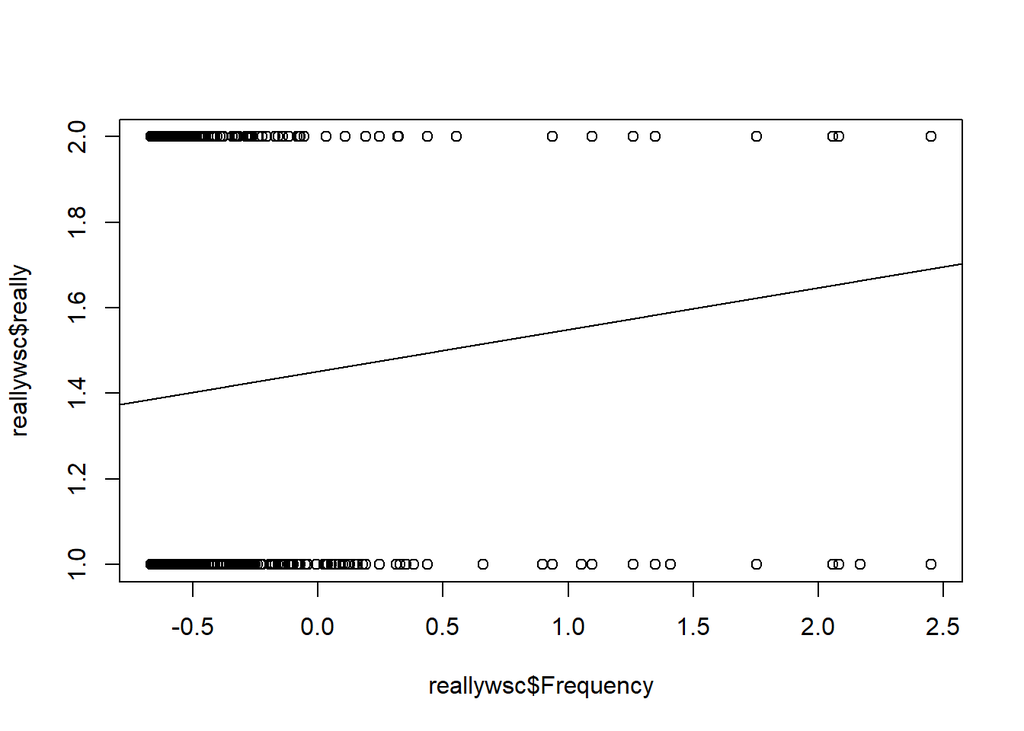

```r
plot(reallywsc$Frequency, reallywsc$really)
abline(lm(reallywsc$really ~reallywsc$Frequency))
```

Next, we scale Gradability. We begin by inspecting it.

```r
# gradability
reallywsc$Gradability <- as.vector(scale(reallywsc$Gradability-1))
summary(reallywsc$Gradability)
```

```
##    Min. 1st Qu.  Median    Mean 3rd Qu.    Max.
## -1.3139 -1.3139  0.1027  0.0000  0.8743  2.7069
```

Next, we scale Gradability. We begin by inspecting it.

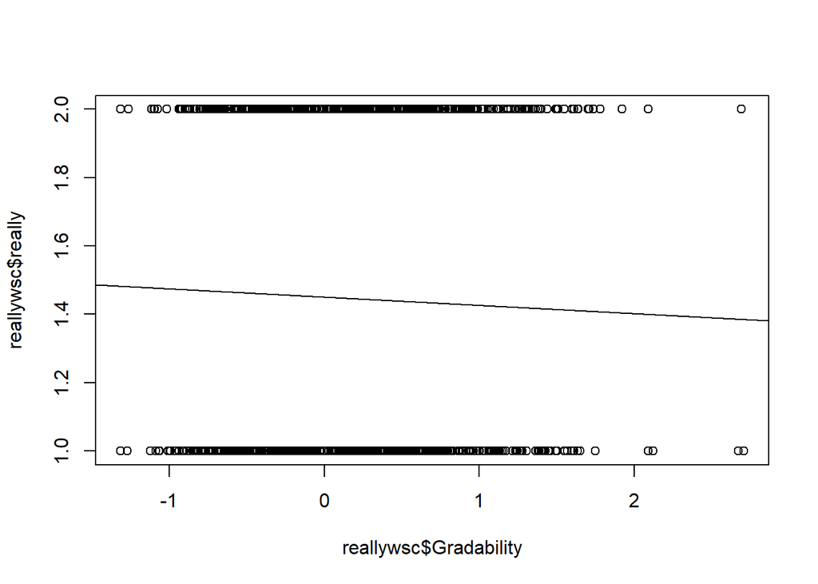

```r
plot(reallywsc$Gradability, reallywsc$really)
abline(lm(reallywsc$really ~ reallywsc$Gradability))
```

Next, we perform the Boruta analysis and begin by using only the variables that we feed to the Boruta analysis, save the data, and start a first Boruta run.

```r
# load library
library(Boruta)
# create dada for boruta
borutadata <- reallywsc %>%
  na.omit()
# save and load data
write.table(borutadata, "datatables/borutadata.txt", sep = "\t",
            col.names = T, row.names = F, quote = F)
# run 1
boruta.reallywsc <- Boruta(really ~.,data=borutadata)
print(boruta.reallywsc)
```

```
## Boruta performed 27 iterations in 10.88509 secs.
##  8 attributes confirmed important: Adjective, Age, Emotionality,
## Ethnicity, Frequency and 3 more;
##  4 attributes confirmed unimportant: Education, Function, Gradability,
## L1;
```

Next, we extract the confirmed Boruta formula to see which variables are deemed important.

```r
getConfirmedFormula(boruta.reallywsc)
```

```
## really ~ Adjective + Ethnicity + Gender + Age + Frequency + Priming +
##     SemanticCategory + Emotionality
## <environment: 0x000000001f01ae50>
```

Next, we plot the results of the first Boruta run.

```r
png("images/BorutaVeryWsc.png",  width = 1800, height = 300)
plot(boruta.reallywsc, cex = .75)
dev.off()
```

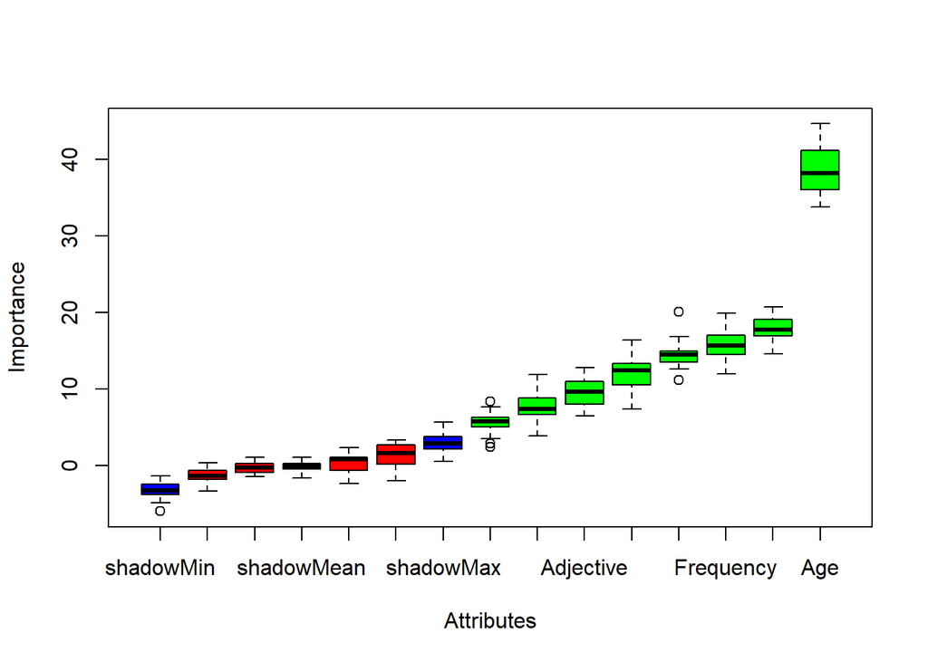

```r
plot(boruta.reallywsc)
```

Next, we plot the history of the first Boruta run.

```r
png("images/BorutaVeryWsc_History1.png",  width = 680, height = 480)
plotImpHistory(boruta.reallywsc)
dev.off()
```

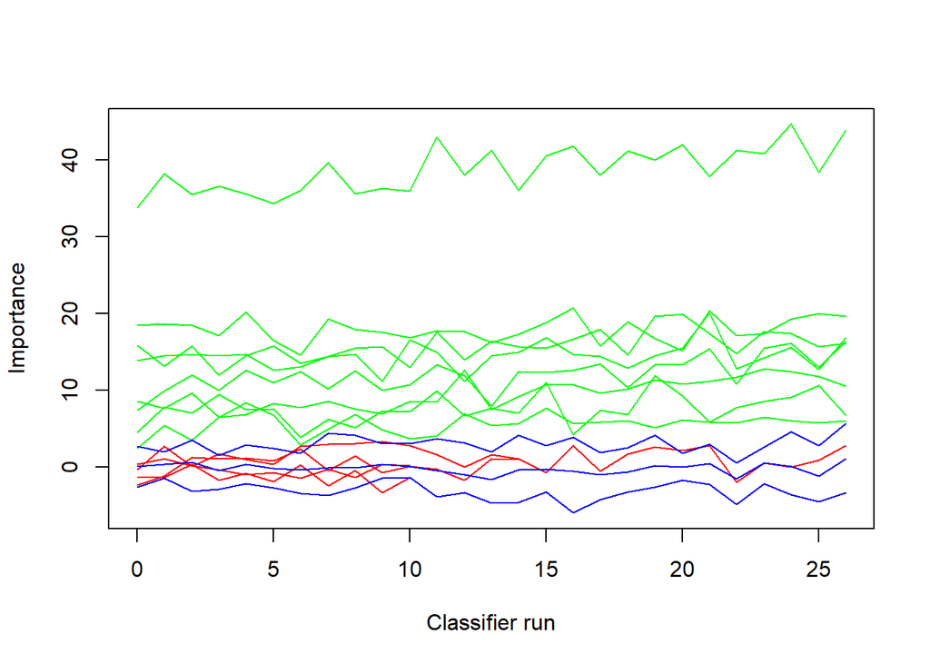

```r
plotImpHistory(boruta.reallywsc)
```

Next, we remove those variables that are deemed unimportant by the first Boruta run and proceed with a second run.

```r
# remove superfluous variables
borutadata$Gradability <- NULL
borutadata$Function <- NULL
borutadata$Education <- NULL
borutadata$L1 <- NULL
# run2
boruta.reallywsc <- Boruta(really~.,data=borutadata)
print(boruta.reallywsc)
```

```
## Boruta performed 10 iterations in 3.783467 secs.
##  8 attributes confirmed important: Adjective, Age, Emotionality,
## Ethnicity, Frequency and 3 more;
##  No attributes deemed unimportant.
```

Next, we retreive the variables deemed important by the Boruta analysis by retrieving the forumla.

```r
getConfirmedFormula(boruta.reallywsc)
```

```
## really ~ Adjective + Ethnicity + Gender + Age + Frequency + Priming +
##     SemanticCategory + Emotionality
## <environment: 0x000000001e0a8d98>
```

Next, we plot the reslts of the second Boruta run.

```r
png("images/BorutaVeryWsc2.png",  width = 1200, height = 300)
plot(boruta.reallywsc, cex = .75)
dev.off()
```

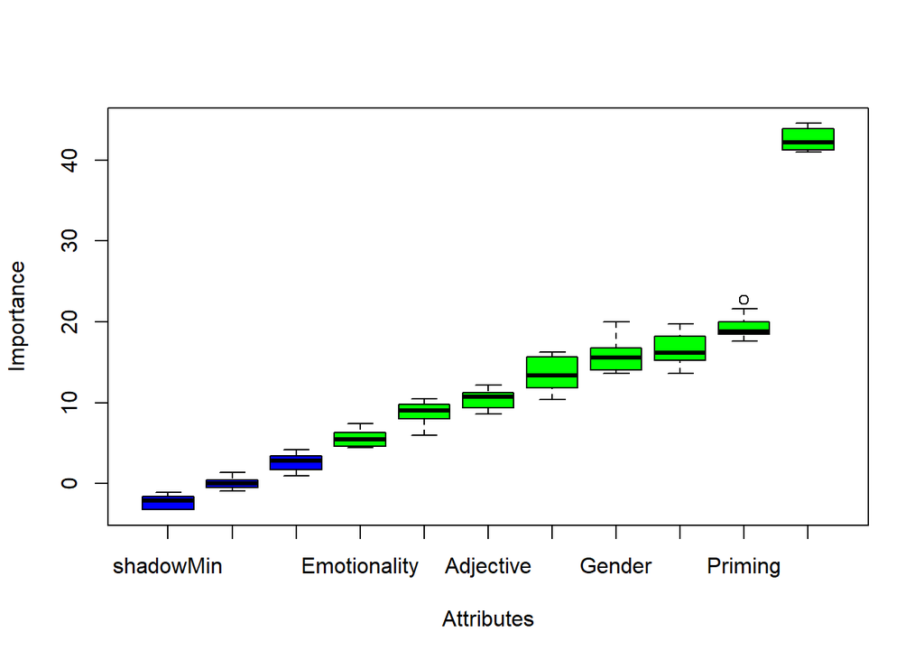

```r
plot(boruta.reallywsc)
```

Next, we plot the history of the second Boruta run.

```r
png("images/BorutaNSP_History2.png",  width = 680, height = 480)
plotImpHistory(boruta.reallywsc)
dev.off()
```

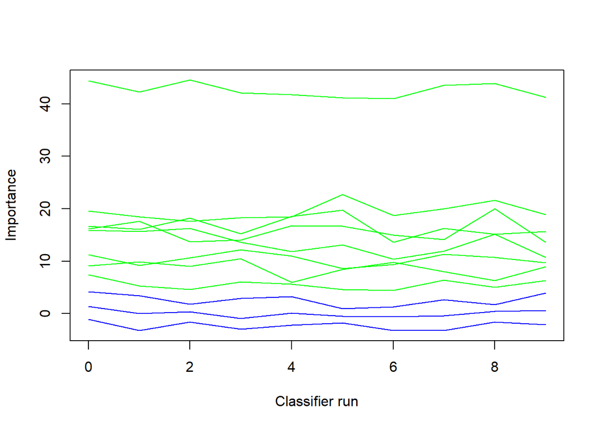

```r
plotImpHistory(boruta.reallywsc)
```

Next, we plot a publishable version of the Boruta results.

```r
png("images/BorutaVeryWsc_final.png",  width = 1500, height = 750)
par(mar = c(22, 8, 4, 2) + 0.1)
plot(boruta.reallywsc, cex.axis=3, las=2, xlab="", ylab = "", cex = 3,
     col = c(rep("grey50", 8), rep("grey90",3)))
abline(v = 3.5, lty = "dashed")
mtext("Predictors", 1, line = 21, at = 9, cex = 3)
mtext("Control", 1, line = 21, at = 2, cex = 3)
mtext("Importance", 2, line = 5, at = 25, cex = 3, las = 0)
dev.off()
```

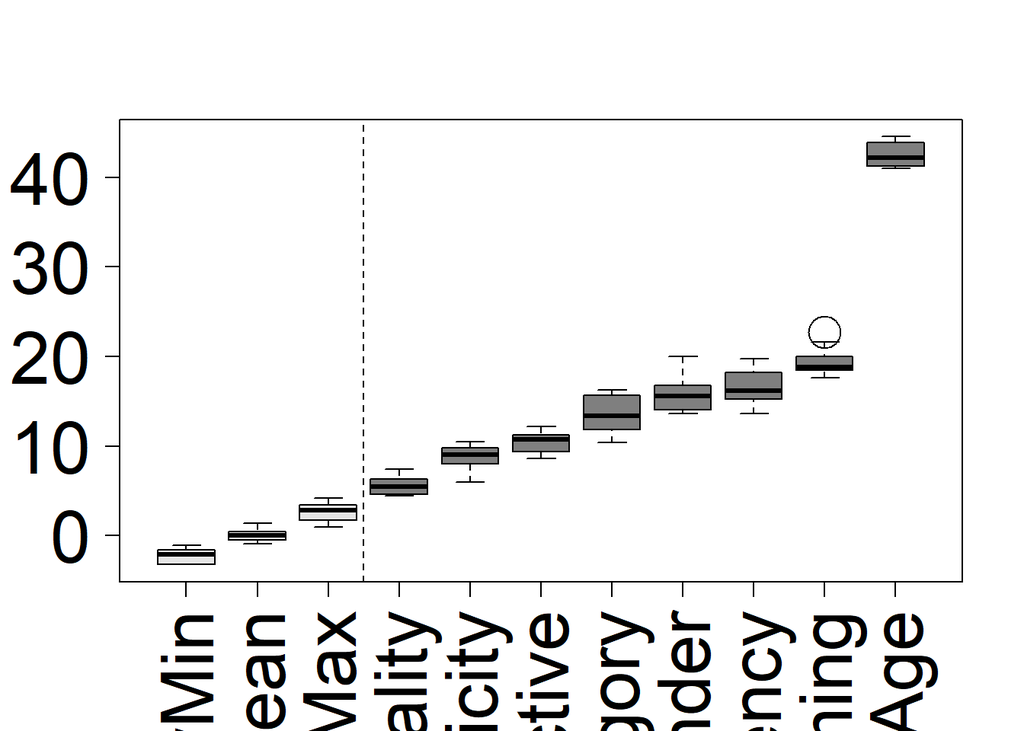

```r
plot(boruta.reallywsc, cex.axis=3, las=2, xlab="", ylab = "", cex = 3,
     col = c(rep("grey50", 8), rep("grey90",3)))
abline(v = 3.5, lty = "dashed")
mtext("Predictors", 1, line = 21, at = 9, cex = 3)
mtext("Control", 1, line = 21, at = 2, cex = 3)
mtext("Importance", 2, line = 5, at = 25, cex = 3, las = 0)
```

```r
par(mar = c(5, 4, 4, 2) + 0.1)
```

Now, we start with the regression modelling and begin by loading the packages, setting options for contarsts, and creating fixed-effects base-line models.

```r
# load library
library(rms)
# set options
options(contrasts  =c("contr.treatment", "contr.poly"))
reallywsc.dist <- datadist(reallywsc)
options(datadist = "reallywsc.dist")
# generate initial minimal regression model
m0.glm = glm(really ~ 1, family = binomial, data = reallywsc) # baseline model glm
m0.lrm = lrm(really ~ 1, data = reallywsc, x = T, y = T) # baseline model lrm
# inspect results
summary(m0.glm)
```

```
##
## Call:
## glm(formula = really ~ 1, family = binomial, data = reallywsc)
##
## Deviance Residuals:
##    Min      1Q  Median      3Q     Max
## -1.096  -1.096  -1.096   1.261   1.261
##
## Coefficients:
##             Estimate Std. Error z value  Pr(>|z|)
## (Intercept) -0.19537    0.04852  -4.026 0.0000567 ***
## ---
## Signif. codes:  0 '***' 0.001 '**' 0.01 '*' 0.05 '.' 0.1 ' ' 1
##
## (Dispersion parameter for binomial family taken to be 1)
##
##     Null deviance: 2361.2  on 1714  degrees of freedom
## Residual deviance: 2361.2  on 1714  degrees of freedom
## AIC: 2363.2
##
## Number of Fisher Scoring iterations: 3
```

Now, we load packages for mixed-effects modelling and create a mixed-effects base-line model.

```r
# load libraries
library(lme4)
library(car)
# create model with a random intercept for token
m0.glmer = glmer(really ~ (1|Adjective), data = reallywsc, family = binomial,
                  control=glmerControl(optimizer="bobyqa"))
```

Now, check if including the random effect is permitted by comparing the aic from the glm to aic from the glmer model.

```r
aic.glmer <- AIC(logLik(m0.glmer))
aic.glm <- AIC(logLik(m0.glm))
aic.glmer; aic.glm
```

```
## [1] 2262.844
```

```
## [1] 2363.207
```

The AIC of the glmer object is smaller which shows that including the random intercepts is justified. In addition, we test if including the random intercepts is justified statistically using a likelihood ratio test.

```r
# test random effects
null.id = -2 * logLik(m0.glm) + 2 * logLik(m0.glmer)
pchisq(as.numeric(null.id), df=1, lower.tail=F)
```

```
## [1] 0.000000000000000000000004622855
```

The mixed-effects model (m0.glmer) has a significantly better fit than the fixed effects model (m0.glm). We continue by inspecting the results of the mixed-effects baseline model.

```r
# inspect results
summary(m0.glmer)
```

```
## Generalized linear mixed model fit by maximum likelihood (Laplace
##   Approximation) [glmerMod]
##  Family: binomial  ( logit )
## Formula: really ~ (1 | Adjective)
##    Data: reallywsc
## Control: glmerControl(optimizer = "bobyqa")
##
##      AIC      BIC   logLik deviance df.resid
##   2262.8   2273.7  -1129.4   2258.8     1713
##
## Scaled residuals:
##     Min      1Q  Median      3Q     Max
## -1.4450 -0.7746 -0.5628  0.9307  2.1331
##
## Random effects:
##  Groups    Name        Variance Std.Dev.
##  Adjective (Intercept) 0.5301   0.7281
## Number of obs: 1715, groups:  Adjective, 261
##
## Fixed effects:
##             Estimate Std. Error z value       Pr(>|z|)
## (Intercept) -0.61267    0.09181  -6.673 0.000000000025 ***
## ---
## Signif. codes:  0 '***' 0.001 '**' 0.01 '*' 0.05 '.' 0.1 ' ' 1
```

Now, we continue with the model fitting. We use a step-wise step-up procedure with vif cutoffs of 5 for main effects and 30 for interactions. We start by adding Age.

```r
# add Age
ifelse(min(ftable(reallywsc$Age, reallywsc$really)) == 0, "not possible", "possible")
```

```
## [1] "possible"
```

```r
m1.glm <- update(m0.glm, .~.+Age)
m1.glmer <- update(m0.glmer, .~.+Age)
anova(m0.glmer, m1.glmer, test = "Chi")
```

```
## Data: reallywsc
## Models:
## m0.glmer: really ~ (1 | Adjective)
## m1.glmer: really ~ (1 | Adjective) + Age
##          Df    AIC    BIC  logLik deviance  Chisq Chi Df            Pr(>Chisq)
## m0.glmer  2 2262.8 2273.7 -1129.4   2258.8
## m1.glmer  6 2149.5 2182.2 -1068.7   2137.5 121.38      4 < 0.00000000000000022
##
## m0.glmer
## m1.glmer ***
## ---
## Signif. codes:  0 '***' 0.001 '**' 0.01 '*' 0.05 '.' 0.1 ' ' 1
```

```r
Anova(m1.glmer, type = "III", test = "Chi")
```

```
## Analysis of Deviance Table (Type III Wald chisquare tests)
##
## Response: really
##               Chisq Df           Pr(>Chisq)
## (Intercept)  3.5969  1              0.05789 .
## Age         98.7627  4 < 0.0000000000000002 ***
## ---
## Signif. codes:  0 '***' 0.001 '**' 0.01 '*' 0.05 '.' 0.1 ' ' 1
```

We retain Age because it is significant. We continue by adding Priming.

```r
# add Priming
m2.glm <- update(m1.glm, .~.+Priming)
max(vif(m2.glm)[,1])
```

```
## [1] 1.015145
```

```r
m2.glmer <- update(m1.glmer, .~.+Priming)
anova(m2.glmer, m1.glmer, test = "Chi")
```

```
## Data: reallywsc
## Models:
## m1.glmer: really ~ (1 | Adjective) + Age
## m2.glmer: really ~ (1 | Adjective) + Age + Priming
##          Df    AIC    BIC  logLik deviance  Chisq Chi Df       Pr(>Chisq)
## m1.glmer  6 2149.5 2182.2 -1068.7   2137.5
## m2.glmer  7 2105.6 2143.8 -1045.8   2091.6 45.833      1 0.00000000001288 ***
## ---
## Signif. codes:  0 '***' 0.001 '**' 0.01 '*' 0.05 '.' 0.1 ' ' 1
```

```r
Anova(m2.glmer, type = "III", test = "Chi")
```

```
## Analysis of Deviance Table (Type III Wald chisquare tests)
##
## Response: really
##               Chisq Df            Pr(>Chisq)
## (Intercept)  7.2262  1              0.007185 **
## Age         93.7558  4 < 0.00000000000000022 ***
## Priming     43.7393  1      0.00000000003752 ***
## ---
## Signif. codes:  0 '***' 0.001 '**' 0.01 '*' 0.05 '.' 0.1 ' ' 1
```

Although including Priming does not lead to substantial collinearity (vifs < 5) and we retain it in the model because it is significant. We continue by adding Frequency.

```r
# add Frequency
ifelse(min(ftable(reallywsc$Frequency, reallywsc$really)) == 0, "not possible", "possible")
```

```
## [1] "not possible"
```

```r
m3.glm <- update(m2.glm, .~.+Frequency)
max(vif(m3.glm)[,1])
```

```
## [1] 1.024458
```

```r
m3.glmer <- update(m2.glmer, .~.+Frequency)
anova(m3.glmer, m2.glmer, test = "Chi")
```

```
## Data: reallywsc
## Models:
## m2.glmer: really ~ (1 | Adjective) + Age + Priming
## m3.glmer: really ~ (1 | Adjective) + Age + Priming + Frequency
##          Df    AIC    BIC  logLik deviance  Chisq Chi Df Pr(>Chisq)
## m2.glmer  7 2105.6 2143.8 -1045.8   2091.6
## m3.glmer  8 2107.6 2151.1 -1045.8   2091.6 0.0786      1     0.7792
```

Including Frequency does not lead to substantial collinearity (vifs < 5) but we do not retain it in the model because it is not significant. We continue by adding Gender.

```r
# add Gender
ifelse(min(ftable(reallywsc$Gender, reallywsc$really)) == 0, "not possible", "possible")
```

```
## [1] "possible"
```

```r
m4.glm <- update(m2.glm, .~.+Gender)
max(vif(m4.glm)[,1])
```

```
## [1] 1.022499
```

```r
m4.glmer <- update(m2.glmer, .~.+Gender)
anova(m4.glmer, m2.glmer, test = "Chi")
```

```
## Data: reallywsc
## Models:
## m2.glmer: really ~ (1 | Adjective) + Age + Priming
## m4.glmer: really ~ (1 | Adjective) + Age + Priming + Gender
##          Df    AIC    BIC  logLik deviance  Chisq Chi Df       Pr(>Chisq)
## m2.glmer  7 2105.6 2143.8 -1045.8   2091.6
## m4.glmer  8 2063.9 2107.4 -1023.9   2047.9 43.768      1 0.00000000003698 ***
## ---
## Signif. codes:  0 '***' 0.001 '**' 0.01 '*' 0.05 '.' 0.1 ' ' 1
```

```r
Anova(m4.glmer, type = "III", test = "Chi")
```

```
## Analysis of Deviance Table (Type III Wald chisquare tests)
##
## Response: really
##              Chisq Df            Pr(>Chisq)
## (Intercept) 31.435  1       0.0000000206213 ***
## Age         91.599  4 < 0.00000000000000022 ***
## Priming     41.401  1       0.0000000001240 ***
## Gender      42.335  1       0.0000000000769 ***
## ---
## Signif. codes:  0 '***' 0.001 '**' 0.01 '*' 0.05 '.' 0.1 ' ' 1
```

Including Gender does not lead to substantial collinearity (vifs < 5) and we retain it in the model because it is significant. We continue by adding SemanticCategory.

```r
# add SemanticCategory
ifelse(min(ftable(reallywsc$SemanticCategory, reallywsc$really)) == 0, "not possible", "possible")
```

```
## [1] "possible"
```

```r
m5.glm <- update(m4.glm, .~.+SemanticCategory)
max(vif(m5.glm)[,1])
```

```
## [1] 1.061496
```

```r
m5.glmer <- update(m4.glmer, .~.+Gradability)
anova(m5.glmer, m4.glmer, test = "Chi")
```

```
## Data: reallywsc
## Models:
## m4.glmer: really ~ (1 | Adjective) + Age + Priming + Gender
## m5.glmer: really ~ (1 | Adjective) + Age + Priming + Gender + Gradability
##          Df    AIC    BIC  logLik deviance  Chisq Chi Df Pr(>Chisq)
## m4.glmer  8 2063.9 2107.4 -1023.9   2047.9
## m5.glmer  9 2065.8 2114.8 -1023.9   2047.8 0.1099      1     0.7402
```

```r
# add Ethnicity
m6.glm <- update(m4.glm, .~.+Ethnicity)
max(vif(m6.glm)[,1])
```

```
## [1] 1.094986
```

```r
m6.glmer <- update(m4.glmer, .~.+Ethnicity)
anova(m6.glmer, m4.glmer, test = "Chi")
```

```
## Data: reallywsc
## Models:
## m4.glmer: really ~ (1 | Adjective) + Age + Priming + Gender
## m6.glmer: really ~ (1 | Adjective) + Age + Priming + Gender + Ethnicity
##          Df    AIC    BIC  logLik deviance  Chisq Chi Df Pr(>Chisq)
## m4.glmer  8 2063.9 2107.4 -1023.9   2047.9
## m6.glmer 11 2059.9 2119.9 -1019.0   2038.0 9.9095      3    0.01935 *
## ---
## Signif. codes:  0 '***' 0.001 '**' 0.01 '*' 0.05 '.' 0.1 ' ' 1
```

```r
Anova(m6.glmer, type = "III", test = "Chi")
```

```
## Analysis of Deviance Table (Type III Wald chisquare tests)
##
## Response: really
##               Chisq Df            Pr(>Chisq)
## (Intercept) 27.9096  1       0.0000001271175 ***
## Age         82.6856  4 < 0.00000000000000022 ***
## Priming     39.6758  1       0.0000000002998 ***
## Gender      41.0147  1       0.0000000001511 ***
## Ethnicity    9.7578  3               0.02074 *
## ---
## Signif. codes:  0 '***' 0.001 '**' 0.01 '*' 0.05 '.' 0.1 ' ' 1
```

Including Ethnicity does not lead to substantial collinearity (vifs < 5) and we retain it in the model because it is significant. We continue by adding Emotionality.

```r
# add Emotionality
ifelse(min(ftable(reallywsc$Emotionality, reallywsc$really)) == 0, "not possible", "possible")
```

```
## [1] "possible"
```

```r
m7.glm <- update(m6.glm, .~.+Emotionality)
max(vif(m7.glm)[,1])
```

```
## [1] 1.101547
```

```r
m7.glmer <- update(m6.glmer, .~.+Emotionality)
anova(m7.glmer, m6.glmer, test = "Chi")
```

```
## Data: reallywsc
## Models:
## m6.glmer: really ~ (1 | Adjective) + Age + Priming + Gender + Ethnicity
## m7.glmer: really ~ (1 | Adjective) + Age + Priming + Gender + Ethnicity +
## m7.glmer:     Emotionality
##          Df    AIC    BIC  logLik deviance  Chisq Chi Df Pr(>Chisq)
## m6.glmer 11 2059.9 2119.9 -1019.0   2038.0
## m7.glmer 13 2063.6 2134.4 -1018.8   2037.6 0.3481      2     0.8403
```

```r
# find all 2-way interactions
library(utils)
vars <- c("Age", "Priming", "Frequency", "Gender", "SemanticCategory",
          "Ethnicity",  "Emotionality")
intac <- t(combn(vars, 2))
intac
```

```
##       [,1]               [,2]
##  [1,] "Age"              "Priming"
##  [2,] "Age"              "Frequency"
##  [3,] "Age"              "Gender"
##  [4,] "Age"              "SemanticCategory"
##  [5,] "Age"              "Ethnicity"
##  [6,] "Age"              "Emotionality"
##  [7,] "Priming"          "Frequency"
##  [8,] "Priming"          "Gender"
##  [9,] "Priming"          "SemanticCategory"
## [10,] "Priming"          "Ethnicity"
## [11,] "Priming"          "Emotionality"
## [12,] "Frequency"        "Gender"
## [13,] "Frequency"        "SemanticCategory"
## [14,] "Frequency"        "Ethnicity"
## [15,] "Frequency"        "Emotionality"
## [16,] "Gender"           "SemanticCategory"
## [17,] "Gender"           "Ethnicity"
## [18,] "Gender"           "Emotionality"
## [19,] "SemanticCategory" "Ethnicity"
## [20,] "SemanticCategory" "Emotionality"
## [21,] "Ethnicity"        "Emotionality"
```

We continue by adding the interactions in a step-wise step-up manner. The cutoff for collienarity is a variance inflation factor of 30 as we expect the variable that are involved in interactions to correlate with the interaction itself and thus are more leniant comapred with main effects. We start by adding the interaction between Age and Priming.

```r
# add Age * Priming
ifelse(min(ftable(reallywsc$Age, reallywsc$Priming, reallywsc$really)) == 0, "not possible", "possible")
```

```
## [1] "possible"
```

```r
m8.glm <- update(m6.glm, .~.+Age * Priming)
max(vif(m8.glm)[,1])
```

```
## [1] 10.65862
```

```r
m8.glmer <- update(m6.glmer, .~.+Age * Priming)
anova(m8.glmer, m6.glmer, test = "Chi")
```

```
## Data: reallywsc
## Models:
## m6.glmer: really ~ (1 | Adjective) + Age + Priming + Gender + Ethnicity
## m8.glmer: really ~ (1 | Adjective) + Age + Priming + Gender + Ethnicity +
## m8.glmer:     Age:Priming
##          Df    AIC    BIC logLik deviance  Chisq Chi Df Pr(>Chisq)
## m6.glmer 11 2059.9 2119.9  -1019   2038.0
## m8.glmer 15 2057.9 2139.6  -1014   2027.9 10.034      4    0.03986 *
## ---
## Signif. codes:  0 '***' 0.001 '**' 0.01 '*' 0.05 '.' 0.1 ' ' 1
```

```r
Anova(m8.glmer, type = "III", test = "Chi")
```

```
## Analysis of Deviance Table (Type III Wald chisquare tests)
##
## Response: really
##               Chisq Df       Pr(>Chisq)
## (Intercept) 30.5328  1 0.00000003282681 ***
## Age         56.0926  4 0.00000000001917 ***
## Priming     14.3511  1        0.0001517 ***
## Gender      40.8715  1 0.00000000016257 ***
## Ethnicity   10.3107  3        0.0161013 *
## Age:Priming  8.6866  4        0.0694280 .
## ---
## Signif. codes:  0 '***' 0.001 '**' 0.01 '*' 0.05 '.' 0.1 ' ' 1
```

Including the interaction between Age and Priming does not lead to substantial collinearity (vifs < 30) but we do not retain it in the model because it is not significant on the variable level. We continue by adding the interaction between Age and Frequency.

```r
# add Age * Frequency
m9.glm <- update(m6.glm, .~.+Age * Frequency)
max(vif(m9.glm)[,1])
```

```
## [1] 10.13632
```

```r
m9.glmer <- update(m6.glmer, .~.+Age * Frequency)
anova(m9.glmer, m6.glmer, test = "Chi")
```

```
## Data: reallywsc
## Models:
## m6.glmer: really ~ (1 | Adjective) + Age + Priming + Gender + Ethnicity
## m9.glmer: really ~ (1 | Adjective) + Age + Priming + Gender + Ethnicity +
## m9.glmer:     Frequency + Age:Frequency
##          Df    AIC    BIC  logLik deviance  Chisq Chi Df Pr(>Chisq)
## m6.glmer 11 2059.9 2119.9 -1019.0   2038.0
## m9.glmer 16 2067.5 2154.7 -1017.8   2035.5 2.4263      5     0.7876
```

Including the interaction between Age and Frequency does not lead to substantial collinearity (vifs < 30) but we do not retain it in the model because it is not significant. We continue by adding the interaction between Age and Gender.

```r
# add Age * Gender
ifelse(min(ftable(reallywsc$Age, reallywsc$Gender, reallywsc$really)) == 0, "not possible", "possible")
```

```
## [1] "possible"
```

```r
m10.glm <- update(m6.glm, .~.+Age * Gender)
max(vif(m10.glm)[,1])
```

```
## [1] 207.0074
```

Including the interaction between Age and Gender leads to substantial collinearity (vifs = 207) and we do not retain it in the model. We thus continue by adding the interaction between Age and SemanticCategory.

```r
# add Age * SemanticCategory
ifelse(min(ftable(reallywsc$Age, reallywsc$SemanticCategory, reallywsc$really)) == 0, "not possible", "possible")
```

```
## [1] "not possible"
```

Including the interaction between Age and SemanticCategory is not possible due to incomplete information and we thus continue by adding the interaction between Age and Ethnicity.

```r
# add Age * Ethnicity
ifelse(min(ftable(reallywsc$Age, reallywsc$Ethnicity, reallywsc$really)) == 0, "not possible", "possible")
```

```
## [1] "not possible"
```

Including the interaction between Age and Ethnicity is not possible due to incomplete information and we thus continue by adding the interaction between Age and Emotionality.

```r
# add Age * Emotionality
ifelse(min(ftable(reallywsc$Age, reallywsc$Emotionality, reallywsc$really)) == 0, "not possible", "possible")
```

```
## [1] "possible"
```

```r
m11.glm <- update(m6.glm, .~.+Age * Emotionality)
max(vif(m11.glm)[,1])
```

```
## [1] 49019.45
```

```r
# add Priming * Frequency
m12.glm <- update(m6.glm, .~.+Priming * Frequency)
max(vif(m12.glm)[,1])
```

```
## [1] 1.263256
```

```r
m12.glmer <- update(m6.glmer, .~.+Priming * Frequency)
anova(m12.glmer, m6.glmer, test = "Chi")
```

```
## Data: reallywsc
## Models:
## m6.glmer: really ~ (1 | Adjective) + Age + Priming + Gender + Ethnicity
## m12.glmer: really ~ (1 | Adjective) + Age + Priming + Gender + Ethnicity +
## m12.glmer:     Frequency + Priming:Frequency
##           Df    AIC    BIC  logLik deviance  Chisq Chi Df Pr(>Chisq)
## m6.glmer  11 2059.9 2119.9 -1019.0     2038
## m12.glmer 13 2063.1 2133.9 -1018.5     2037 0.9084      2     0.6349
```

Including the interaction between Priming and Frequency does not lead to substantial collinearity (vifs < 30) but we do not retain it in the model because it is not significant. We continue with adding the interaction between Priming and Gender.

```r
# add Priming * Gender
ifelse(min(ftable(reallywsc$Priming, reallywsc$Gender, reallywsc$really)) == 0, "not possible", "possible")
```

```
## [1] "possible"
```

```r
m13.glm <- update(m6.glm, .~.+Priming * Gender)
max(vif(m13.glm)[,1])
```

```
## [1] 3.220376
```

```r
m13.glmer <- update(m6.glmer, .~.+Priming * Gender)
anova(m13.glmer, m6.glmer, test = "Chi")
```

```
## Data: reallywsc
## Models:
## m6.glmer: really ~ (1 | Adjective) + Age + Priming + Gender + Ethnicity
## m13.glmer: really ~ (1 | Adjective) + Age + Priming + Gender + Ethnicity +
## m13.glmer:     Priming:Gender
##           Df    AIC    BIC  logLik deviance  Chisq Chi Df Pr(>Chisq)
## m6.glmer  11 2059.9 2119.9 -1019.0   2038.0
## m13.glmer 12 2058.6 2124.0 -1017.3   2034.6 3.3331      1     0.0679 .
## ---
## Signif. codes:  0 '***' 0.001 '**' 0.01 '*' 0.05 '.' 0.1 ' ' 1
```

```r
Anova(m13.glmer, type = "III", test = "Chi")
```

```
## Analysis of Deviance Table (Type III Wald chisquare tests)
##
## Response: really
##                  Chisq Df            Pr(>Chisq)
## (Intercept)    24.7439  1          0.0000006548 ***
## Age            81.9321  4 < 0.00000000000000022 ***
## Priming         4.3986  1               0.03597 *
## Gender         26.5355  1          0.0000002587 ***
## Ethnicity      10.2246  3               0.01675 *
## Priming:Gender  3.3258  1               0.06820 .
## ---
## Signif. codes:  0 '***' 0.001 '**' 0.01 '*' 0.05 '.' 0.1 ' ' 1
```

```r
# add Priming * SemanticCategory
ifelse(min(ftable(reallywsc$Priming, reallywsc$SemanticCategory, reallywsc$really)) == 0, "not possible", "possible")
```

```
## [1] "not possible"
```

Including the interaction between Priming and SemanticCategory is not possible due to incomplete information and we thus continue by adding the interaction between Priming and Ethnicity.

```r
# add Priming * Ethnicity
ifelse(min(ftable(reallywsc$Priming, reallywsc$Ethnicity, reallywsc$really)) == 0, "not possible", "possible")
```

```
## [1] "possible"
```

```r
m14.glm <- update(m6.glm, .~.+Priming * Ethnicity)
max(vif(m14.glm)[,1])
```

```
## [1] 18.91741
```

```r
m14.glmer <- update(m6.glmer, .~.+Priming * Ethnicity)
anova(m14.glmer, m6.glmer, test = "Chi")
```

```
## Data: reallywsc
## Models:
## m6.glmer: really ~ (1 | Adjective) + Age + Priming + Gender + Ethnicity
## m14.glmer: really ~ (1 | Adjective) + Age + Priming + Gender + Ethnicity +
## m14.glmer:     Priming:Ethnicity
##           Df    AIC    BIC  logLik deviance  Chisq Chi Df Pr(>Chisq)
## m6.glmer  11 2059.9 2119.9 -1019.0   2038.0
## m14.glmer 14 2064.8 2141.0 -1018.4   2036.8 1.1819      3     0.7574
```

Including the interaction between Priming and Ethnicity does not lead to substantial collinearity (vifs < 30) but we do not retain it in the model because it is not significant. We continue with adding the interaction between Priming and SemanticCategory.

```r
ifelse(min(ftable(reallywsc$Priming, reallywsc$SemanticCategory, reallywsc$really)) == 0, "not possible", "possible")
```

```
## [1] "not possible"
```

```r
# add Priming * Emotionality
ifelse(min(ftable(reallywsc$Priming, reallywsc$Emotionality, reallywsc$really)) == 0, "not possible", "possible")
```

```
## [1] "possible"
```

```r
m15.glm <- update(m6.glm, .~.+Priming * Emotionality)
max(vif(m15.glm)[,1])
```

```
## [1] 9.199318
```

```r
m15.glmer <- update(m6.glmer, .~.+Priming * Emotionality)
anova(m15.glmer, m6.glmer, test = "Chi")
```

```
## Data: reallywsc
## Models:
## m6.glmer: really ~ (1 | Adjective) + Age + Priming + Gender + Ethnicity
## m15.glmer: really ~ (1 | Adjective) + Age + Priming + Gender + Ethnicity +
## m15.glmer:     Emotionality + Priming:Emotionality
##           Df    AIC    BIC  logLik deviance  Chisq Chi Df Pr(>Chisq)
## m6.glmer  11 2059.9 2119.9 -1019.0   2038.0
## m15.glmer 15 2063.6 2145.3 -1016.8   2033.6 4.3261      4     0.3637
```

Including the interaction between Priming and Emotionality does not lead to substantial collinearity (vifs < 30) but we do not retain it in the model because it is not significant. We continue with adding the interaction between Frequency and Gender.

```r
# add Frequency * Gender
m16.glm <- update(m6.glm, .~.+Frequency * Gender)
max(vif(m16.glm)[,1])
```

```
## [1] 2.64047
```

```r
m16.glmer <- update(m6.glmer, .~.+Frequency * Gender)
anova(m16.glmer, m6.glmer, test = "Chi")
```

```
## Data: reallywsc
## Models:
## m6.glmer: really ~ (1 | Adjective) + Age + Priming + Gender + Ethnicity
## m16.glmer: really ~ (1 | Adjective) + Age + Priming + Gender + Ethnicity +
## m16.glmer:     Frequency + Gender:Frequency
##           Df    AIC    BIC  logLik deviance  Chisq Chi Df Pr(>Chisq)
## m6.glmer  11 2059.9 2119.9 -1019.0   2038.0
## m16.glmer 13 2063.9 2134.7 -1018.9   2037.9 0.0795      2      0.961
```

Including the interaction between Frequency and Gender does not lead to substantial collinearity (vifs < 30) but we do not retain it in the model because it is not significant. We continue with adding the interaction between Frequency and SemanticCategory.

```r
# add Frequency * SemanticCategory
m17.glm <- update(m6.glm, .~.+Frequency * SemanticCategory)
max(vif(m14.glm)[,1])
```

```
## [1] 18.91741
```

```r
# add Frequency * Ethnicity
m18.glm <- update(m6.glm, .~.+Frequency * Ethnicity)
max(vif(m18.glm)[,1])
```

```
## [1] 9.829963
```

```r
m18.glmer <- update(m6.glmer, .~.+Frequency * Ethnicity)
anova(m18.glmer, m6.glmer, test = "Chi")
```

```
## Data: reallywsc
## Models:
## m6.glmer: really ~ (1 | Adjective) + Age + Priming + Gender + Ethnicity
## m18.glmer: really ~ (1 | Adjective) + Age + Priming + Gender + Ethnicity +
## m18.glmer:     Frequency + Ethnicity:Frequency
##           Df    AIC    BIC  logLik deviance  Chisq Chi Df Pr(>Chisq)
## m6.glmer  11 2059.9 2119.9 -1019.0   2038.0
## m18.glmer 15 2063.2 2144.9 -1016.6   2033.2 4.7853      4       0.31
```

Including the interaction between Frequency and Ethnicity does not lead to substantial collinearity (vifs < 30) but we do not retain it in the model because it is not significant. We continue with adding the interaction between Frequency and Emotionality

```r
# add Frequency * Emotionality
m19.glm <- update(m6.glm, .~.+Frequency * Emotionality)
max(vif(m19.glm)[,1])
```

```
## [1] 206.2069
```

```r
# add Gender * SemanticCategory
ifelse(min(ftable(reallywsc$Gender, reallywsc$SemanticCategory, reallywsc$really)) == 0, "not possible", "possible")
```

```
## [1] "possible"
```

```r
m20.glm <- update(m6.glm, .~.+Gender * SemanticCategory)
max(vif(m20.glm)[,1])
```

```
## [1] 915288.3
```

Including the interaction between Gender and SemanticCategory leads to unacceptable collinearity (vifs > 30) and we thus do not retain it in the model. We continue with adding the interaction between Gender and SemanticCategory.

```r
# add Gender * Ethnicity
ifelse(min(ftable(reallywsc$Gender, reallywsc$Ethnicity, reallywsc$really)) == 0, "not possible", "possible")
```

```
## [1] "possible"
```

```r
m21.glm <- update(m6.glm, .~.+Gender * Ethnicity)
max(vif(m21.glm)[,1])
```

```
## [1] 107.6619
```

Including the interaction between Gender and Ethnicity leads to unacceptable collinearity (vifs > 30) and we thus do not retain it in the model. We continue with adding the interaction between Gender and Emotionality.

```r
# add Gender * Emotionality
ifelse(min(ftable(reallywsc$Gender, reallywsc$Emotionality, reallywsc$really)) == 0, "not possible", "possible")
```

```
## [1] "possible"
```

```r
m22.glm <- update(m6.glm, .~.+Gender * Emotionality)
max(vif(m22.glm)[,1])
```

```
## [1] 25.39566
```

```r
m22.glmer <- update(m6.glmer, .~.+Gender * Emotionality)
anova(m22.glmer, m6.glmer, test = "Chi")
```

```
## Data: reallywsc
## Models:
## m6.glmer: really ~ (1 | Adjective) + Age + Priming + Gender + Ethnicity
## m22.glmer: really ~ (1 | Adjective) + Age + Priming + Gender + Ethnicity +
## m22.glmer:     Emotionality + Gender:Emotionality
##           Df    AIC    BIC  logLik deviance  Chisq Chi Df Pr(>Chisq)
## m6.glmer  11 2059.9 2119.9 -1019.0   2038.0
## m22.glmer 15 2064.8 2146.5 -1017.4   2034.8 3.1999      4      0.525
```

Including the interaction between Gender and Emotionality does not lead to substantial collinearity (vifs < 30) but we do not retain it in the model because it is not significant. We continue with adding the interaction between Gender and Emotionality.

```r
# add SemanticCategory * Ethnicity
ifelse(min(ftable(reallywsc$SemanticCategory, reallywsc$Ethnicity, reallywsc$really)) == 0, "not possible", "possible")
```

```
## [1] "not possible"
```

Including the interaction between SemanticCategory and Ethnicity is not possible due to incomplete information and we thus continue by adding the interaction between SemanticCategory and Emotionality.

```r
# add SemanticCategory * Emotionality
ifelse(min(ftable(reallywsc$SemanticCategory, reallywsc$Emotionality, reallywsc$really)) == 0, "not possible", "possible")
```

```
## [1] "not possible"
```

Including the interaction between SemanticCategory and Emotionality is not possible due to incomplete information and we thus continue by adding the interaction between Ethnicity and Emotionality.

```r
# add Ethnicity * Emotionality
ifelse(min(ftable(reallywsc$Ethnicity, reallywsc$Emotionality, reallywsc$really)) == 0, "not possible", "possible")
```

```
## [1] "possible"
```

```r
m23.glm <- update(m6.glm, .~.+Ethnicity * Emotionality)
max(vif(m23.glm)[,1])
```

```
## [1] 4680.341
```

```r
# find all 2-way interactions
library(utils)
vars <- c("Age", "Priming", "Frequency", "Gender", "SemanticCategory",
          "Ethnicity",  "Emotionality")
intac <- t(combn(vars, 3))
intac
```

```
##       [,1]               [,2]               [,3]
##  [1,] "Age"              "Priming"          "Frequency"
##  [2,] "Age"              "Priming"          "Gender"
##  [3,] "Age"              "Priming"          "SemanticCategory"
##  [4,] "Age"              "Priming"          "Ethnicity"
##  [5,] "Age"              "Priming"          "Emotionality"
##  [6,] "Age"              "Frequency"        "Gender"
##  [7,] "Age"              "Frequency"        "SemanticCategory"
##  [8,] "Age"              "Frequency"        "Ethnicity"
##  [9,] "Age"              "Frequency"        "Emotionality"
## [10,] "Age"              "Gender"           "SemanticCategory"
## [11,] "Age"              "Gender"           "Ethnicity"
## [12,] "Age"              "Gender"           "Emotionality"
## [13,] "Age"              "SemanticCategory" "Ethnicity"
## [14,] "Age"              "SemanticCategory" "Emotionality"
```

[output cut: 21 more lines]

Check which of these interactions can be tested.

```r
AgePrimingFrequency <- ifelse(min(ftable(reallywsc$Age, reallywsc$Priming, reallywsc$Frequency)) == 0, "not possible", "possible")
AgePrimingGender <- ifelse(min(ftable(reallywsc$Age, reallywsc$Priming, reallywsc$Gender)) == 0, "not possible", "possible")
AgePrimingSemanticCategory <- ifelse(min(ftable(reallywsc$Age, reallywsc$Priming, reallywsc$SemanticCategory)) == 0, "not possible", "possible")
AgePrimingEthnicity <- ifelse(min(ftable(reallywsc$Age, reallywsc$Priming, reallywsc$Ethnicity)) == 0, "not possible", "possible")
AgePrimingEmotionality <- ifelse(min(ftable(reallywsc$Age,
reallywsc$Priming, reallywsc$Emotionality)) == 0, "not possible", "possible")
AgeFrequencyGender <- ifelse(min(ftable(reallywsc$Age, reallywsc$Frequency, reallywsc$Gender)) == 0, "not possible", "possible")
AgeFrequencySemanticCategory <- ifelse(min(ftable(reallywsc$Age, reallywsc$Frequency, reallywsc$SemanticCategory)) == 0, "not possible", "possible")
AgeFrequencyEthnicity <- ifelse(min(ftable(reallywsc$Age, reallywsc$Frequency, reallywsc$Ethnicity)) == 0, "not possible", "possible")
AgeFrequencyEmotionality <- ifelse(min(ftable(reallywsc$Age, reallywsc$Frequency, reallywsc$Emotionality)) == 0, "not possible", "possible")
AgeGenderSemanticCategory <- ifelse(min(ftable(reallywsc$Age, reallywsc$Gender, reallywsc$SemanticCategory)) == 0, "not possible", "possible")
AgeGenderEthnicity <- ifelse(min(ftable(reallywsc$Age, reallywsc$Gender, reallywsc$Ethnicity)) == 0, "not possible", "possible")
AgeGenderEmotionality <- ifelse(min(ftable(reallywsc$Age, reallywsc$Gender, reallywsc$Emotionality)) == 0, "not possible", "possible")
AgeSemanticCategoryEthnicity <- ifelse(min(ftable(reallywsc$Age, reallywsc$SemanticCategory, reallywsc$Ethnicity)) == 0, "not possible", "possible")
AgeSemanticCategoryEmotionality <- ifelse(min(ftable(reallywsc$Age, reallywsc$SemanticCategory, reallywsc$Emotionality)) == 0, "not possible", "possible")
AgeEthnicityEmotionality <- ifelse(min(ftable(reallywsc$Age, reallywsc$Ethnicity, reallywsc$Emotionality)) == 0, "not possible", "possible")
PrimingFrequencyGender <- ifelse(min(ftable(reallywsc$Priming, reallywsc$Frequency, reallywsc$Gender)) == 0, "not possible", "possible")
PrimingFrequencySemanticCategory <- ifelse(min(ftable(reallywsc$Priming, reallywsc$Frequency, reallywsc$SemanticCategory)) == 0, "not possible", "possible")
PrimingFrequencyEthnicity <- ifelse(min(ftable(reallywsc$Priming, reallywsc$Frequency, reallywsc$Ethnicity)) == 0, "not possible", "possible")
PrimingFrequencyEmotionality <- ifelse(min(ftable(reallywsc$Priming, reallywsc$Frequency, reallywsc$Emotionality)) == 0, "not possible", "possible")
PrimingGenderSemanticCategory <- ifelse(min(ftable(reallywsc$Priming, reallywsc$Gender, reallywsc$SemanticCategory)) == 0, "not possible", "possible")
PrimingGenderEthnicity <- ifelse(min(ftable(reallywsc$Priming, reallywsc$Gender, reallywsc$Ethnicity)) == 0, "not possible", "possible")
PrimingGenderEmotionality <- ifelse(min(ftable(reallywsc$Priming, reallywsc$Gender, reallywsc$Emotionality)) == 0, "not possible", "possible")
PrimingSemanticCategoryEthnicity <- ifelse(min(ftable(reallywsc$Priming, reallywsc$SemanticCategory, reallywsc$Ethnicity)) == 0, "not possible", "possible")
PrimingSemanticCategoryEmotionality <- ifelse(min(ftable(reallywsc$Priming, reallywsc$SemanticCategory, reallywsc$Emotionality)) == 0, "not possible", "possible")
PrimingEthnicityEmotionality <- ifelse(min(ftable(reallywsc$Priming, reallywsc$Ethnicity, reallywsc$Emotionality)) == 0, "not possible", "possible")
FrequencyGenderSemanticCategory <- ifelse(min(ftable(reallywsc$Frequency, reallywsc$Gender, reallywsc$SemanticCategory)) == 0, "not possible", "possible")
FrequencyGenderEthnicity <- ifelse(min(ftable(reallywsc$Frequency, reallywsc$Gender, reallywsc$Ethnicity)) == 0, "not possible", "possible")
FrequencyGenderEmotionality <- ifelse(min(ftable(reallywsc$Frequency, reallywsc$Gender, reallywsc$Emotionality)) == 0, "not possible", "possible")
FrequencySemanticCategoryEthnicity <- ifelse(min(ftable(reallywsc$Frequency, reallywsc$SemanticCategory, reallywsc$Ethnicity)) == 0, "not possible", "possible")
FrequencySemanticCategoryEmotionality <- ifelse(min(ftable(reallywsc$Frequency, reallywsc$SemanticCategory, reallywsc$Emotionality)) == 0, "not possible", "possible")
FrequencyEthnicityEmotionality <- ifelse(min(ftable(reallywsc$Frequency, reallywsc$Ethnicity, reallywsc$Emotionality)) == 0, "not possible", "possible")
GenderSemanticCategoryEthnicity <- ifelse(min(ftable(reallywsc$Gender, reallywsc$SemanticCategory, reallywsc$Ethnicity)) == 0, "not possible", "possible")
GenderSemanticCategoryEmotionality <- ifelse(min(ftable(reallywsc$Gender, reallywsc$SemanticCategory, reallywsc$Emotionality)) == 0, "not possible", "possible")
GenderEthnicityEmotionality <- ifelse(min(ftable(reallywsc$Gender, reallywsc$Ethnicity, reallywsc$Emotionality)) == 0, "not possible", "possible")
SemanticCategoryEthnicityEmotionality <- ifelse(min(ftable(reallywsc$SemanticCategory, reallywsc$Ethnicity, reallywsc$Emotionality)) == 0, "not possible", "possible")
```

```r
AgePrimingFrequency
```

```
## [1] "not possible"
```

```r
AgePrimingGender
```

```
## [1] "possible"
```

```r
AgePrimingSemanticCategory
```

```
## [1] "not possible"
```

```r
AgePrimingEthnicity
```

```
## [1] "not possible"
```

```r
AgePrimingEmotionality
```

```
## [1] "possible"
```

```r
AgeFrequencyGender
```

```
## [1] "not possible"
```

```r
AgeFrequencySemanticCategory
```

```
## [1] "not possible"
```

```r
AgeFrequencyEthnicity
```

```
## [1] "not possible"
```

```r
AgeFrequencyEmotionality
```

```
## [1] "not possible"
```

```r
AgeGenderSemanticCategory
```

```
## [1] "not possible"
```

```r
AgeGenderEthnicity
```

```
## [1] "not possible"
```

```r
AgeGenderEmotionality
```

```
## [1] "possible"
```

```r
AgeSemanticCategoryEthnicity
```

```
## [1] "not possible"
```

```r
AgeSemanticCategoryEmotionality
```

```
## [1] "not possible"
```

```r
AgeEthnicityEmotionality
```

```
## [1] "not possible"
```

```r
PrimingFrequencyGender
```

```
## [1] "not possible"
```

```r
PrimingFrequencySemanticCategory
```

```
## [1] "not possible"
```

```r
PrimingFrequencyEthnicity
```

```
## [1] "not possible"
```

```r
PrimingFrequencyEmotionality
```

```
## [1] "not possible"
```

```r
PrimingGenderSemanticCategory
```

```
## [1] "not possible"
```

```r
PrimingGenderEthnicity
```

```
## [1] "possible"
```

```r
PrimingGenderEmotionality
```

```
## [1] "possible"
```

```r
PrimingSemanticCategoryEthnicity
```

```
## [1] "not possible"
```

```r
PrimingSemanticCategoryEmotionality
```

```
## [1] "not possible"
```

```r
PrimingEthnicityEmotionality
```

```
## [1] "not possible"
```

```r
FrequencyGenderSemanticCategory
```

```
## [1] "not possible"
```

```r
FrequencyGenderEthnicity
```

```
## [1] "not possible"
```

```r
FrequencyGenderEmotionality
```

```
## [1] "not possible"
```

```r
FrequencySemanticCategoryEthnicity
```

```
## [1] "not possible"
```

```r
FrequencySemanticCategoryEmotionality
```

```
## [1] "not possible"
```

```r
FrequencyEthnicityEmotionality
```

```
## [1] "not possible"
```

```r
GenderSemanticCategoryEthnicity
```

```
## [1] "not possible"
```

```r
GenderSemanticCategoryEmotionality
```

```
## [1] "not possible"
```

```r
GenderEthnicityEmotionality
```

```
## [1] "possible"
```

```r
SemanticCategoryEthnicityEmotionality
```

```
## [1] "not possible"
```

Possible combinations are: * AgePrimingGender * AgePrimingEmotionality  
* AgeGenderEmotionality * PrimingGenderEthnicity  
* PrimingGenderEmotionality * GenderEthnicityEmotionality

We continue by adding the interactions in a step-wise step-up manner. The cutoff for collienarity is a variance inflation factor of 30 as we expect the variable that are involved in interactions to correlate with the interaction itself and thus are more leniant comapred with main effects. We start by adding the interaction between Age, Priming, and Gender.

```r
# add Age * Priming * Gender
m24.glm <- update(m6.glm, .~.+Age * Priming * Gender)
max(vif(m24.glm)[,1])
```

```
## [1] 105508238
```

Including the interaction between Age, Priming, and Gender leads to unacceptable collinearity (vifs > 30) and we thus do not retain it in the model. We continue with adding the interaction between Age, Priming, and Emotionality.

```r
# add Age * Priming * Emotionality
m25.glm <- update(m6.glm, .~.+Age * Priming * Emotionality)
max(vif(m25.glm)[,1])
```

```
## [1] 13867183451379564
```

Including the interaction between Age, Priming, and Emotionality leads to unacceptable collinearity (vifs > 30) and we thus do not retain it in the model. We continue with adding the interaction between Age, Gender, and Emotionality.

```r
# add Age * Gender * Emotionality
m26.glm <- update(m6.glm, .~.+Age * Priming * Emotionality)
max(vif(m26.glm)[,1])
```

```
## [1] 13867183451379564
```

```r
# add Age * Gender * Emotionality
m27.glm <- update(m6.glm, .~.+Age * Gender * Emotionality)
max(vif(m27.glm)[,1])
```

```
## [1] 11015332750063616000
```

Including the interaction between Age, Gender, and Emotionality leads to unacceptable collinearity (vifs > 30) and we thus do not retain it in the model. We continue with adding the interaction between Priming, Gender, and Ethnicity.

```r
# add Priming * Gender * Ethnicity
m28.glm <- update(m6.glm, .~.+Priming * Gender * Ethnicity)
max(vif(m28.glm)[,1])
```

```
## [1] 16477456
```

Including the interaction between Priming, Gender, and Ethnicity leads to unacceptable collinearity (vifs > 30) and we thus do not retain it in the model. We continue with adding the interaction between Priming, Gender, and Emotionality.

```r
# add Priming * Gender * Emotionality.
m29.glm <- update(m6.glm, .~.+Priming * Gender * Emotionality)
max(vif(m29.glm)[,1])
```

```
## [1] 87.16081
```

Including the interaction between Priming, Gender, and Emotionality leads to unacceptable collinearity (vifs > 30) and we thus do not retain it in the model. We continue with adding the interaction between Gender, Ethnicity, and Emotionality.

```r
# add Gender * Ethnicity * Emotionality
m30.glm <- update(m6.glm, .~.+Gender * Ethnicity * Emotionality)
max(vif(m30.glm)[,1])
```

```
## [1] 9704361
```

Including the interaction between Gender, Ethnicity, and Emotionality leads to unacceptable collinearity (vifs > 30) and we thus do not retain it in the model. We continue with inspecting the final model.

```r
summary(m6.glmer)
```

```
## Generalized linear mixed model fit by maximum likelihood (Laplace
##   Approximation) [glmerMod]
##  Family: binomial  ( logit )
## Formula: really ~ (1 | Adjective) + Age + Priming + Gender + Ethnicity
##    Data: reallywsc
## Control: glmerControl(optimizer = "bobyqa")
##
##      AIC      BIC   logLik deviance df.resid
##   2060.0   2119.9  -1019.0   2038.0     1704
##
## Scaled residuals:
##     Min      1Q  Median      3Q     Max
## -2.7487 -0.7647 -0.3249  0.8184  3.9504
##
## Random effects:
##  Groups    Name        Variance Std.Dev.
##  Adjective (Intercept) 0.3868   0.6219
## Number of obs: 1715, groups:  Adjective, 261
##
## Fixed effects:
##                       Estimate Std. Error z value         Pr(>|z|)
## (Intercept)           -1.40726    0.26638  -5.283 0.00000012711753 ***
## Age20-29               0.08226    0.15012   0.548          0.58375
## Age30-39              -0.10541    0.20598  -0.512          0.60881
## Age40-49              -0.99669    0.24084  -4.138 0.00003498543291 ***
## Age50+                -1.92733    0.26852  -7.178 0.00000000000071 ***
## PrimingPrime           0.95120    0.15101   6.299 0.00000000029981 ***
## GenderWoman            0.78318    0.12229   6.404 0.00000000015109 ***
## EthnicityMAORI/PAKEHA -0.04134    0.34796  -0.119          0.90543
## EthnicityOTHER         0.69027    0.26030   2.652          0.00801 **
## EthnicityPAKEHA        0.43297    0.20464   2.116          0.03437 *
## ---
## Signif. codes:  0 '***' 0.001 '**' 0.01 '*' 0.05 '.' 0.1 ' ' 1
##
## Correlation of Fixed Effects:
##             (Intr) A20-29 A30-39 A40-49 Age50+ PrmngP GndrWm EMAORI EOTHER
## Age20-29    -0.484
## Age30-39    -0.432  0.546
## Age40-49    -0.354  0.459  0.363
## Age50+      -0.293  0.412  0.315  0.284
## PrimingPrim -0.069 -0.047  0.016  0.024 -0.073
## GenderWoman -0.375  0.077  0.030  0.014  0.013  0.013
## EMAORI/PAKE -0.445  0.010  0.057  0.095  0.070  0.008  0.042
## EthnctOTHER -0.597  0.014  0.148  0.137  0.100 -0.024  0.015  0.433
## EthncPAKEHA -0.746  0.078  0.147  0.110  0.069 -0.009  0.015  0.534  0.717
```

We begin the diagnostics with visualizing residuals.

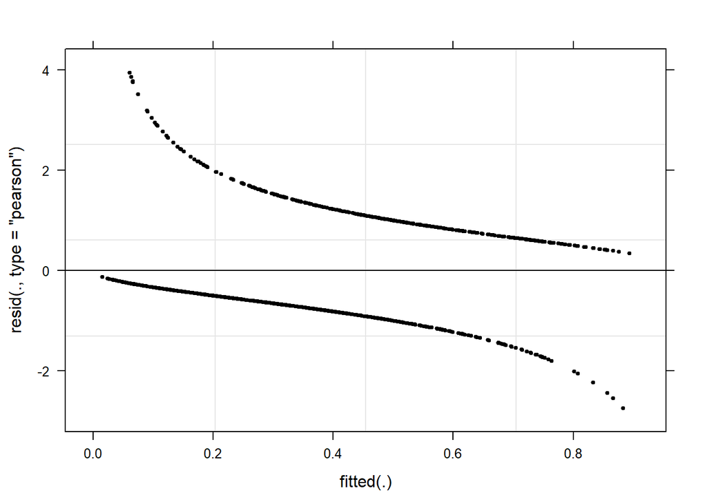

```r
par(mfrow = c(1, 4))   # display plots in 3 rows and 2 columns
plot(m6.glmer, col = "black", pch = 20); par(mfrow = c(1, 1))
```

We now plot Cook’s distance to check if we need to remove data points and include a data-driven cutoff threshold (which is likely too low).

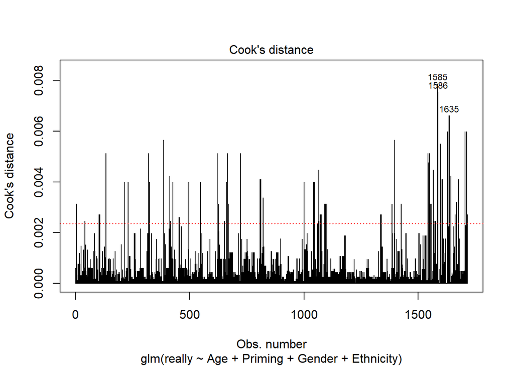

```r
# determine a cutoff for data points that have D-values higher than 4/(n-k-1)
cutoff <- 4/((nrow(reallywsc)-length(coefficients(m6.glm)-2)))
# plot cook*s distance
plot(m6.glm, which=4, cook.levels = cutoff)
abline(h = cutoff, col = "red", lty = "dotted")
```

We continue the diagnostics using the glm model and visualizing its residuals.

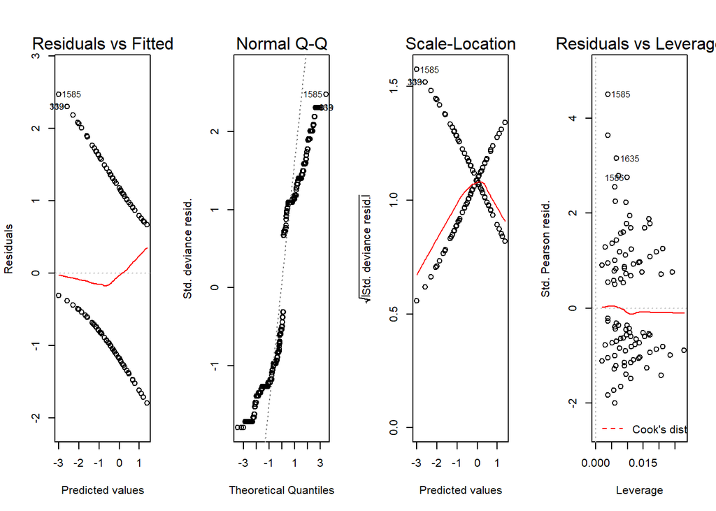

```r
cutoff <- 0.0065
# start plotting
par(mfrow = c(1, 4))
plot(m6.glm); par(mfrow = c(1, 4))
```

The diagnostics show that the data do not fit the assumptions of the model really well but there is not much we can do except removing outliers. We will do this and rerun the analysis.

```r
reallywsc$cooksdistance <- cooks.distance(m6.glm)
reallywscnew <- reallywsc[-(which(reallywsc$cooksdistance > cutoff)),]
# save new data set to disc
write.table(reallywscnew, "datatables/reallywscnew.txt", row.names= F, sep = "\t")
nrow(reallywsc); nrow(reallywscnew)
```

```
## [1] 1715
```

```
## [1] 1711
```

```r
(which(reallywscnew$cooksdistance > cutoff))
```

```
## integer(0)
```

There are no more data points with Cook’s diance values above the cutoff in the data.

We begin the rerun of the model fitting by setting options and creating intercept-only base-line models.

```r
# load library
library(rms)
# set options
options(contrasts  =c("contr.treatment", "contr.poly"))
reallywscnew.dist <- datadist(reallywscnew)
options(datadist = "reallywscnew.dist")
# generate initial minimal regression model
m0.glm = glm(really ~ 1, family = binomial, data = reallywscnew) # baseline model glm
m0.lrm = lrm(really ~ 1, data = reallywscnew, x = T, y = T) # baseline model lrm
# inspect results
summary(m0.glm)
```

```
##
## Call:
## glm(formula = really ~ 1, family = binomial, data = reallywscnew)
##
## Deviance Residuals:
##    Min      1Q  Median      3Q     Max
## -1.094  -1.094  -1.094   1.264   1.264
##
## Coefficients:
##             Estimate Std. Error z value  Pr(>|z|)
## (Intercept) -0.20055    0.04859  -4.127 0.0000367 ***
## ---
## Signif. codes:  0 '***' 0.001 '**' 0.01 '*' 0.05 '.' 0.1 ' ' 1
##
## (Dispersion parameter for binomial family taken to be 1)
##
##     Null deviance: 2354.8  on 1710  degrees of freedom
## Residual deviance: 2354.8  on 1710  degrees of freedom
## AIC: 2356.8
##
## Number of Fisher Scoring iterations: 3
```

Now, we load packages for mixed-effects modelling and create a mixed-effects base-line model.

```r
# load libraries
library(lme4)
library(car)
# create model with a random intercept for token
m0.glmer = glmer(really ~ (1|Adjective), data = reallywscnew,
                 family = binomial,
                 control=glmerControl(optimizer="bobyqa"))
```

Now, check if including the random effect is permitted by comparing the aic from the glm to aic from the glmer model.

```r
aic.glmer <- AIC(logLik(m0.glmer))
aic.glm <- AIC(logLik(m0.glm))
aic.glmer; aic.glm
```

```
## [1] 2258.3
```

```
## [1] 2356.831
```

The AIC of the glmer object is smaller which shows that including the random intercepts is justified. In addition, we test if including the random intercepts is justified statistically using a likelihood ratio test.

```r
# test random effects
null.id = -2 * logLik(m0.glm) + 2 * logLik(m0.glmer)
pchisq(as.numeric(null.id), df=1, lower.tail=F)
```

```
## [1] 0.00000000000000000000001165291
```

The mixed-effects model (m0.glmer) has a significantly better fit than the fixed effects model (m0.glm). We continue by inspecting the results of the mixed-effects baseline model.

```r
# inspect results
summary(m0.glmer)
```

```
## Generalized linear mixed model fit by maximum likelihood (Laplace
##   Approximation) [glmerMod]
##  Family: binomial  ( logit )
## Formula: really ~ (1 | Adjective)
##    Data: reallywscnew
## Control: glmerControl(optimizer = "bobyqa")
##
##      AIC      BIC   logLik deviance df.resid
##   2258.3   2269.2  -1127.1   2254.3     1709
##
## Scaled residuals:
##     Min      1Q  Median      3Q     Max
## -1.4445 -0.7798 -0.5629  0.9311  2.1320
##
## Random effects:
##  Groups    Name        Variance Std.Dev.
##  Adjective (Intercept) 0.5285   0.727
## Number of obs: 1711, groups:  Adjective, 261
##
## Fixed effects:
##             Estimate Std. Error z value        Pr(>|z|)
## (Intercept) -0.61311    0.09173  -6.684 0.0000000000233 ***
## ---
## Signif. codes:  0 '***' 0.001 '**' 0.01 '*' 0.05 '.' 0.1 ' ' 1
```

Now, we continue with the model fitting. We use a step-wise step-up procedure with vif cutoffs of 5 for main effects and 30 for interactions. We start by adding Age.

```r
# add Age
ifelse(min(ftable(reallywscnew$Age, reallywscnew$really)) == 0, "not possible", "possible")
```

```
## [1] "possible"
```

```r
m1.glm <- update(m0.glm, .~.+Age)
m1.glmer <- update(m0.glmer, .~.+Age)
anova(m0.glmer, m1.glmer, test = "Chi")
```

```
## Data: reallywscnew
## Models:
## m0.glmer: really ~ (1 | Adjective)
## m1.glmer: really ~ (1 | Adjective) + Age
##          Df    AIC    BIC  logLik deviance  Chisq Chi Df            Pr(>Chisq)
## m0.glmer  2 2258.3 2269.2 -1127.2   2254.3
## m1.glmer  6 2135.7 2168.3 -1061.8   2123.7 130.62      4 < 0.00000000000000022
##
## m0.glmer
## m1.glmer ***
## ---
## Signif. codes:  0 '***' 0.001 '**' 0.01 '*' 0.05 '.' 0.1 ' ' 1
```

```r
Anova(m1.glmer, type = "III", test = "Chi")
```

```
## Analysis of Deviance Table (Type III Wald chisquare tests)
##
## Response: really
##                Chisq Df           Pr(>Chisq)
## (Intercept)   3.4128  1              0.06469 .
## Age         101.4685  4 < 0.0000000000000002 ***
## ---
## Signif. codes:  0 '***' 0.001 '**' 0.01 '*' 0.05 '.' 0.1 ' ' 1
```

We retain Age because it is significant. We continue by adding Priming.

```r
# add Priming
m2.glm <- update(m1.glm, .~.+Priming)
max(vif(m2.glm)[,1])
```

```
## [1] 1.015121
```

```r
m2.glmer <- update(m1.glmer, .~.+Priming)
anova(m2.glmer, m1.glmer, test = "Chi")
```

```
## Data: reallywscnew
## Models:
## m1.glmer: really ~ (1 | Adjective) + Age
## m2.glmer: really ~ (1 | Adjective) + Age + Priming
##          Df    AIC    BIC  logLik deviance  Chisq Chi Df       Pr(>Chisq)
## m1.glmer  6 2135.7 2168.3 -1061.8   2123.7
## m2.glmer  7 2091.8 2129.9 -1038.9   2077.8 45.906      1 0.00000000001241 ***
## ---
## Signif. codes:  0 '***' 0.001 '**' 0.01 '*' 0.05 '.' 0.1 ' ' 1
```

```r
Anova(m2.glmer, type = "III", test = "Chi")
```

```
## Analysis of Deviance Table (Type III Wald chisquare tests)
##
## Response: really
##               Chisq Df            Pr(>Chisq)
## (Intercept)  6.9864  1              0.008213 **
## Age         96.4335  4 < 0.00000000000000022 ***
## Priming     43.7574  1      0.00000000003717 ***
## ---
## Signif. codes:  0 '***' 0.001 '**' 0.01 '*' 0.05 '.' 0.1 ' ' 1
```

Although including Priming does not lead to substantial collinearity (vifs < 5) and we retain it in the model because it is significant. We continue by adding Frequency.

```r
# add Frequency
ifelse(min(ftable(reallywscnew$Frequency, reallywscnew$really)) == 0, "not possible", "possible")
```

```
## [1] "not possible"
```

```r
m3.glm <- update(m2.glm, .~.+Frequency)
max(vif(m3.glm)[,1])
```

```
## [1] 1.024738
```

```r
m3.glmer <- update(m2.glmer, .~.+Frequency)
anova(m3.glmer, m2.glmer, test = "Chi")
```

```
## Data: reallywscnew
## Models:
## m2.glmer: really ~ (1 | Adjective) + Age + Priming
## m3.glmer: really ~ (1 | Adjective) + Age + Priming + Frequency
##          Df    AIC    BIC  logLik deviance  Chisq Chi Df Pr(>Chisq)
## m2.glmer  7 2091.8 2129.9 -1038.9   2077.8
## m3.glmer  8 2093.3 2136.9 -1038.7   2077.3 0.4471      1     0.5037
```

Including Frequency does not lead to substantial collinearity (vifs < 5) but we do not retain it in the model because it is not significant. We continue by adding Gender.

```r
# add Gender
ifelse(min(ftable(reallywscnew$Gender, reallywscnew$really)) == 0, "not possible", "possible")
```

```
## [1] "possible"
```

```r
m4.glm <- update(m2.glm, .~.+Gender)
max(vif(m4.glm)[,1])
```

```
## [1] 1.023004
```

```r
m4.glmer <- update(m2.glmer, .~.+Gender)
anova(m4.glmer, m2.glmer, test = "Chi")
```

```
## Data: reallywscnew
## Models:
## m2.glmer: really ~ (1 | Adjective) + Age + Priming
## m4.glmer: really ~ (1 | Adjective) + Age + Priming + Gender
##          Df    AIC    BIC  logLik deviance  Chisq Chi Df       Pr(>Chisq)
## m2.glmer  7 2091.8 2129.9 -1038.9   2077.8
## m4.glmer  8 2049.4 2093.0 -1016.7   2033.4 44.344      1 0.00000000002755 ***
## ---
## Signif. codes:  0 '***' 0.001 '**' 0.01 '*' 0.05 '.' 0.1 ' ' 1
```

```r
Anova(m4.glmer, type = "III", test = "Chi")
```

```
## Analysis of Deviance Table (Type III Wald chisquare tests)
##
## Response: really
##              Chisq Df            Pr(>Chisq)
## (Intercept) 31.319  1      0.00000002188956 ***
## Age         94.766  4 < 0.00000000000000022 ***
## Priming     41.276  1      0.00000000013221 ***
## Gender      42.864  1      0.00000000005869 ***
## ---
## Signif. codes:  0 '***' 0.001 '**' 0.01 '*' 0.05 '.' 0.1 ' ' 1
```

Including Gender does not lead to substantial collinearity (vifs < 5) and we retain it in the model because it is significant. We continue by adding SemanticCategory.

```r
# add SemanticCategory
ifelse(min(ftable(reallywscnew$SemanticCategory, reallywscnew$really)) == 0, "not possible", "possible")
```

```
## [1] "possible"
```

```r
m5.glm <- update(m4.glm, .~.+SemanticCategory)
max(vif(m5.glm)[,1])
```

```
## [1] 1.061849
```

```r
m5.glmer <- update(m4.glmer, .~.+Gradability)
anova(m5.glmer, m4.glmer, test = "Chi")
```

```
## Data: reallywscnew
## Models:
## m4.glmer: really ~ (1 | Adjective) + Age + Priming + Gender
## m5.glmer: really ~ (1 | Adjective) + Age + Priming + Gender + Gradability
##          Df    AIC    BIC  logLik deviance  Chisq Chi Df Pr(>Chisq)
## m4.glmer  8 2049.4 2093.0 -1016.7   2033.4
## m5.glmer  9 2051.3 2100.3 -1016.7   2033.3 0.1019      1     0.7496
```

```r
# add Ethnicity
m6.glm <- update(m4.glm, .~.+Ethnicity)
max(vif(m6.glm)[,1])
```

```
## [1] 1.093193
```

```r
m6.glmer <- update(m4.glmer, .~.+Ethnicity)
anova(m6.glmer, m4.glmer, test = "Chi")
```

```
## Data: reallywscnew
## Models:
## m4.glmer: really ~ (1 | Adjective) + Age + Priming + Gender
## m6.glmer: really ~ (1 | Adjective) + Age + Priming + Gender + Ethnicity
##          Df    AIC    BIC  logLik deviance  Chisq Chi Df Pr(>Chisq)
## m4.glmer  8 2049.4 2093.0 -1016.7   2033.4
## m6.glmer 11 2042.6 2102.5 -1010.3   2020.6 12.795      3   0.005102 **
## ---
## Signif. codes:  0 '***' 0.001 '**' 0.01 '*' 0.05 '.' 0.1 ' ' 1
```

```r
Anova(m6.glmer, type = "III", test = "Chi")
```

```
## Analysis of Deviance Table (Type III Wald chisquare tests)
##
## Response: really
##              Chisq Df            Pr(>Chisq)
## (Intercept) 31.928  1       0.0000000160000 ***
## Age         86.500  4 < 0.00000000000000022 ***
## Priming     39.423  1       0.0000000003412 ***
## Gender      41.729  1       0.0000000001048 ***
## Ethnicity   12.523  3               0.00579 **
## ---
## Signif. codes:  0 '***' 0.001 '**' 0.01 '*' 0.05 '.' 0.1 ' ' 1
```

Including Ethnicity does not lead to substantial collinearity (vifs < 5) and we retain it in the model because it is significant. We continue by adding Emotionality.

```r
# add Emotionality
ifelse(min(ftable(reallywscnew$Emotionality, reallywscnew$really)) == 0, "not possible", "possible")
```

```
## [1] "possible"
```

```r
m7.glm <- update(m6.glm, .~.+Emotionality)
max(vif(m7.glm)[,1])
```

```
## [1] 1.099394
```

```r
m7.glmer <- update(m6.glmer, .~.+Emotionality)
anova(m7.glmer, m6.glmer, test = "Chi")
```

```
## Data: reallywscnew
## Models:
## m6.glmer: really ~ (1 | Adjective) + Age + Priming + Gender + Ethnicity
## m7.glmer: really ~ (1 | Adjective) + Age + Priming + Gender + Ethnicity +
## m7.glmer:     Emotionality
##          Df    AIC    BIC  logLik deviance  Chisq Chi Df Pr(>Chisq)
## m6.glmer 11 2042.6 2102.5 -1010.3   2020.6
## m7.glmer 13 2046.3 2117.1 -1010.1   2020.3 0.3354      2     0.8456
```

```r
# find all 2-way interactions
library(utils)
vars <- c("Age", "Priming", "Frequency", "Gender", "SemanticCategory",
          "Ethnicity",  "Emotionality")
intac <- t(combn(vars, 2))
intac
```

```
##       [,1]               [,2]
##  [1,] "Age"              "Priming"
##  [2,] "Age"              "Frequency"
##  [3,] "Age"              "Gender"
##  [4,] "Age"              "SemanticCategory"
##  [5,] "Age"              "Ethnicity"
##  [6,] "Age"              "Emotionality"
##  [7,] "Priming"          "Frequency"
##  [8,] "Priming"          "Gender"
##  [9,] "Priming"          "SemanticCategory"
## [10,] "Priming"          "Ethnicity"
## [11,] "Priming"          "Emotionality"
## [12,] "Frequency"        "Gender"
## [13,] "Frequency"        "SemanticCategory"
## [14,] "Frequency"        "Ethnicity"
## [15,] "Frequency"        "Emotionality"
## [16,] "Gender"           "SemanticCategory"
## [17,] "Gender"           "Ethnicity"
## [18,] "Gender"           "Emotionality"
## [19,] "SemanticCategory" "Ethnicity"
## [20,] "SemanticCategory" "Emotionality"
## [21,] "Ethnicity"        "Emotionality"
```

We continue by adding the interactions in a step-wise step-up manner. The cutoff for collienarity is a variance inflation factor of 30 as we expect the variable that are involved in interactions to correlate with the interaction itself and thus are more leniant comapred with main effects. We start by adding the interaction between Age and Priming.

```r
# add Age * Priming
ifelse(min(ftable(reallywscnew$Age, reallywscnew$Priming, reallywscnew$really)) == 0, "not possible", "possible")
```

```
## [1] "possible"
```

```r
m8.glm <- update(m6.glm, .~.+Age * Priming)
max(vif(m8.glm)[,1])
```

```
## [1] 10.22079
```

```r
m8.glmer <- update(m6.glmer, .~.+Age * Priming)
anova(m8.glmer, m6.glmer, test = "Chi")
```

```
## Data: reallywscnew
## Models:
## m6.glmer: really ~ (1 | Adjective) + Age + Priming + Gender + Ethnicity
## m8.glmer: really ~ (1 | Adjective) + Age + Priming + Gender + Ethnicity +
## m8.glmer:     Age:Priming
##          Df    AIC    BIC  logLik deviance  Chisq Chi Df Pr(>Chisq)
## m6.glmer 11 2042.6 2102.5 -1010.3   2020.6
## m8.glmer 15 2039.8 2121.5 -1004.9   2009.8 10.831      4    0.02853 *
## ---
## Signif. codes:  0 '***' 0.001 '**' 0.01 '*' 0.05 '.' 0.1 ' ' 1
```

```r
Anova(m8.glmer, type = "III", test = "Chi")
```

```
## Analysis of Deviance Table (Type III Wald chisquare tests)
##
## Response: really
##               Chisq Df        Pr(>Chisq)
## (Intercept) 34.7694  1 0.000000003711647 ***
## Age         59.2686  4 0.000000000004132 ***
## Priming     14.2754  1         0.0001579 ***
## Gender      41.7767  1 0.000000000102317 ***
## Ethnicity   13.2439  3         0.0041378 **
## Age:Priming  8.9022  4         0.0635915 .
## ---
## Signif. codes:  0 '***' 0.001 '**' 0.01 '*' 0.05 '.' 0.1 ' ' 1
```

Including the interaction between Age and Priming does not lead to substantial collinearity (vifs < 30) but we do not retain it in the model because it is not significant on the variable level. We continue by adding the interaction between Age and Frequency.

```r
# add Age * Frequency
m9.glm <- update(m6.glm, .~.+Age * Frequency)
max(vif(m9.glm)[,1])
```

```
## [1] 10.82406
```

```r
m9.glmer <- update(m6.glmer, .~.+Age * Frequency)
anova(m9.glmer, m6.glmer, test = "Chi")
```

```
## Data: reallywscnew
## Models:
## m6.glmer: really ~ (1 | Adjective) + Age + Priming + Gender + Ethnicity
## m9.glmer: really ~ (1 | Adjective) + Age + Priming + Gender + Ethnicity +
## m9.glmer:     Frequency + Age:Frequency
##          Df    AIC    BIC  logLik deviance  Chisq Chi Df Pr(>Chisq)
## m6.glmer 11 2042.6 2102.5 -1010.3   2020.6
## m9.glmer 16 2051.8 2138.9 -1009.9   2019.8 0.8435      5     0.9742
```

Including the interaction between Age and Frequency does not lead to substantial collinearity (vifs < 30) but we do not retain it in the model because it is not significant. We continue by adding the interaction between Age and Gender.

```r
# add Age * Gender
ifelse(min(ftable(reallywscnew$Age, reallywscnew$Gender, reallywscnew$really)) == 0, "not possible", "possible")
```

```
## [1] "possible"
```

```r
m10.glm <- update(m6.glm, .~.+Age * Gender)
max(vif(m10.glm)[,1])
```

```
## [1] 206.9752
```

Including the interaction between Age and Gender leads to unacceptable collinearity (vifs > 100) and we thus do not retain it in the model. We continue by adding the interaction between Age and SemanticCategory.

```r
# add Age * SemanticCategory
ifelse(min(ftable(reallywscnew$Age, reallywscnew$SemanticCategory, reallywscnew$really)) == 0, "not possible", "possible")
```

```
## [1] "not possible"
```

Including the interaction between Age and SemanticCategory is not possible due to incomplete information and we thus continue by adding the interaction between Age and Ethnicity.

```r
# add Age * Ethnicity
ifelse(min(ftable(reallywscnew$Age, reallywscnew$Ethnicity, reallywscnew$really)) == 0, "not possible", "possible")
```

```
## [1] "not possible"
```

Including the interaction between Age and Ethnicity is not possible due to incomplete information and we thus continue by adding the interaction between Age and Emotionality.

```r
# add Age * Emotionality
ifelse(min(ftable(reallywscnew$Age, reallywscnew$Emotionality, reallywscnew$really)) == 0, "not possible", "possible")
```

```
## [1] "possible"
```

```r
m11.glm <- update(m6.glm, .~.+Age * Emotionality)
max(vif(m11.glm)[,1])
```

```
## [1] 42350.31
```

Including the interaction between Age and Emotionality leads to unacceptable collinearity (vifs > 100) and we thus do not retain it in the model. We continue by adding the interaction between Priming and Frequency.

```r
# add Priming * Frequency
m12.glm <- update(m6.glm, .~.+Priming * Frequency)
max(vif(m12.glm)[,1])
```

```
## [1] 1.266719
```

```r
m12.glmer <- update(m6.glmer, .~.+Priming * Frequency)
anova(m12.glmer, m6.glmer, test = "Chi")
```

```
## Data: reallywscnew
## Models:
## m6.glmer: really ~ (1 | Adjective) + Age + Priming + Gender + Ethnicity
## m12.glmer: really ~ (1 | Adjective) + Age + Priming + Gender + Ethnicity +
## m12.glmer:     Frequency + Priming:Frequency
##           Df    AIC    BIC  logLik deviance  Chisq Chi Df Pr(>Chisq)
## m6.glmer  11 2042.6 2102.5 -1010.3   2020.6
## m12.glmer 13 2045.3 2116.1 -1009.6   2019.3 1.3395      2     0.5118
```

Including the interaction between Priming and Frequency does not lead to substantial collinearity (vifs < 30) but we do not retain it in the model because it is not significant. We continue with adding the interaction between Priming and Gender.

```r
# add Priming * Gender
ifelse(min(ftable(reallywscnew$Priming, reallywscnew$Gender, reallywscnew$really)) == 0, "not possible", "possible")
```

```
## [1] "possible"
```

```r
m13.glm <- update(m6.glm, .~.+Priming * Gender)
max(vif(m13.glm)[,1])
```

```
## [1] 3.211204
```

```r
m13.glmer <- update(m6.glmer, .~.+Priming * Gender)
anova(m13.glmer, m6.glmer, test = "Chi")
```

```
## Data: reallywscnew
## Models:
## m6.glmer: really ~ (1 | Adjective) + Age + Priming + Gender + Ethnicity
## m13.glmer: really ~ (1 | Adjective) + Age + Priming + Gender + Ethnicity +
## m13.glmer:     Priming:Gender
##           Df    AIC    BIC  logLik deviance  Chisq Chi Df Pr(>Chisq)
## m6.glmer  11 2042.6 2102.5 -1010.3   2020.6
## m13.glmer 12 2040.8 2106.2 -1008.4   2016.8 3.7972      1    0.05134 .
## ---
## Signif. codes:  0 '***' 0.001 '**' 0.01 '*' 0.05 '.' 0.1 ' ' 1
```

```r
Anova(m13.glmer, type = "III", test = "Chi")
```

```
## Analysis of Deviance Table (Type III Wald chisquare tests)
##
## Response: really
##                  Chisq Df            Pr(>Chisq)
## (Intercept)    28.4612  1         0.00000009559 ***
## Age            85.8712  4 < 0.00000000000000022 ***
## Priming         3.9122  1              0.047938 *
## Gender         26.6163  1         0.00000024814 ***
## Ethnicity      13.0441  3              0.004542 **
## Priming:Gender  3.7870  1              0.051651 .
## ---
## Signif. codes:  0 '***' 0.001 '**' 0.01 '*' 0.05 '.' 0.1 ' ' 1
```

```r
# add Priming * SemanticCategory
ifelse(min(ftable(reallywscnew$Priming, reallywscnew$SemanticCategory, reallywscnew$really)) == 0, "not possible", "possible")
```

```
## [1] "not possible"
```

Including the interaction between Priming and SemanticCategory is not possible due to incomplete information and we thus continue by adding the interaction between Priming and Ethnicity.

```r
# add Priming * Ethnicity
ifelse(min(ftable(reallywscnew$Priming, reallywscnew$Ethnicity, reallywscnew$really)) == 0, "not possible", "possible")
```

```
## [1] "possible"
```

```r
m14.glm <- update(m6.glm, .~.+Priming * Ethnicity)
max(vif(m14.glm)[,1])
```

```
## [1] 19.29297
```

```r
m14.glmer <- update(m6.glmer, .~.+Priming * Ethnicity)
anova(m14.glmer, m6.glmer, test = "Chi")
```

```
## Data: reallywscnew
## Models:
## m6.glmer: really ~ (1 | Adjective) + Age + Priming + Gender + Ethnicity
## m14.glmer: really ~ (1 | Adjective) + Age + Priming + Gender + Ethnicity +
## m14.glmer:     Priming:Ethnicity
##           Df    AIC    BIC  logLik deviance  Chisq Chi Df Pr(>Chisq)
## m6.glmer  11 2042.6 2102.5 -1010.3   2020.6
## m14.glmer 14 2047.6 2123.9 -1009.8   2019.6 0.9939      3     0.8027
```

Including the interaction between Priming and Ethnicity does not lead to substantial collinearity (vifs < 30) but we do not retain it in the model because it is not significant. We continue with adding the interaction between Priming and SemanticCategory.

```r
ifelse(min(ftable(reallywscnew$Priming, reallywscnew$SemanticCategory, reallywscnew$really)) == 0, "not possible", "possible")
```

```
## [1] "not possible"
```

```r
# add Priming * Emotionality
ifelse(min(ftable(reallywscnew$Priming, reallywscnew$Emotionality, reallywscnew$really)) == 0, "not possible", "possible")
```

```
## [1] "possible"
```

```r
m15.glm <- update(m6.glm, .~.+Priming * Emotionality)
max(vif(m15.glm)[,1])
```

```
## [1] 9.197969
```

```r
m15.glmer <- update(m6.glmer, .~.+Priming * Emotionality)
anova(m15.glmer, m6.glmer, test = "Chi")
```

```
## Data: reallywscnew
## Models:
## m6.glmer: really ~ (1 | Adjective) + Age + Priming + Gender + Ethnicity
## m15.glmer: really ~ (1 | Adjective) + Age + Priming + Gender + Ethnicity +
## m15.glmer:     Emotionality + Priming:Emotionality
##           Df    AIC    BIC  logLik deviance Chisq Chi Df Pr(>Chisq)
## m6.glmer  11 2042.6 2102.5 -1010.3   2020.6
## m15.glmer 15 2046.2 2127.9 -1008.1   2016.2 4.386      4     0.3563
```

Including the interaction between Priming and Emotionality does not lead to substantial collinearity (vifs < 30) but we do not retain it in the model because it is not significant. We continue with adding the interaction between Frequency and Gender.

```r
# add Frequency * Gender
m16.glm <- update(m6.glm, .~.+Frequency * Gender)
max(vif(m16.glm)[,1])
```

```
## [1] 2.639445
```

```r
m16.glmer <- update(m6.glmer, .~.+Frequency * Gender)
anova(m16.glmer, m6.glmer, test = "Chi")
```

```
## Data: reallywscnew
## Models:
## m6.glmer: really ~ (1 | Adjective) + Age + Priming + Gender + Ethnicity
## m16.glmer: really ~ (1 | Adjective) + Age + Priming + Gender + Ethnicity +
## m16.glmer:     Frequency + Gender:Frequency
##           Df    AIC    BIC  logLik deviance  Chisq Chi Df Pr(>Chisq)
## m6.glmer  11 2042.6 2102.5 -1010.3   2020.6
## m16.glmer 13 2046.3 2117.0 -1010.1   2020.3 0.3812      2     0.8265
```

Including the interaction between Frequency and Gender does not lead to substantial collinearity (vifs < 30) but we do not retain it in the model because it is not significant. We continue with adding the interaction between Frequency and SemanticCategory.

```r
# add Frequency * SemanticCategory
m17.glm <- update(m6.glm, .~.+Frequency * SemanticCategory)
max(vif(m17.glm)[,1])
```

```
## [1] 26863804896003
```

Including the interaction between Frequency and SemanticCategory leads to unacceptable collinearity (vifs > 100) and we thus do not retain it in the model. We continue with adding the interaction between Frequency and Ethnicity.

```r
# add Frequency * Ethnicity
m18.glm <- update(m6.glm, .~.+Frequency * Ethnicity)
max(vif(m18.glm)[,1])
```

```
## [1] 9.975348
```

```r
m18.glmer <- update(m6.glmer, .~.+Frequency * Ethnicity)
anova(m18.glmer, m6.glmer, test = "Chi")
```

```
## Data: reallywscnew
## Models:
## m6.glmer: really ~ (1 | Adjective) + Age + Priming + Gender + Ethnicity
## m18.glmer: really ~ (1 | Adjective) + Age + Priming + Gender + Ethnicity +
## m18.glmer:     Frequency + Ethnicity:Frequency
##           Df    AIC    BIC  logLik deviance  Chisq Chi Df Pr(>Chisq)
## m6.glmer  11 2042.6 2102.5 -1010.3   2020.6
## m18.glmer 15 2045.3 2127.0 -1007.7   2015.3 5.2952      4     0.2583
```

Including the interaction between Frequency and Ethnicity does not lead to substantial collinearity (vifs < 30) but we do not retain it in the model because it is not significant. We continue with adding the interaction between Frequency and Emotionality

```r
# add Frequency * Emotionality
m19.glm <- update(m6.glm, .~.+Frequency * Emotionality)
max(vif(m19.glm)[,1])
```

```
## [1] 208.7296
```

Including the interaction between Frequency and Emotionality leads to substantial collinearity (vifs = 208) and we thusdo not retain it in the model. We continue with adding the interaction between Gender and SemanticCategory.

```r
# add Gender * SemanticCategory
ifelse(min(ftable(reallywscnew$Gender, reallywscnew$SemanticCategory, reallywscnew$really)) == 0, "not possible", "possible")
```

```
## [1] "possible"
```

```r
m20.glm <- update(m6.glm, .~.+Gender * SemanticCategory)
max(vif(m20.glm)[,1])
```

```
## [1] 892849.1
```

Including the interaction between Gender and SemanticCategory leads to unacceptable collinearity (vifs > 30) and we thus do not retain it in the model. We continue with adding the interaction between Gender and SemanticCategory.

```r
# add Gender * Ethnicity
ifelse(min(ftable(reallywscnew$Gender, reallywscnew$Ethnicity, reallywscnew$really)) == 0, "not possible", "possible")
```

```
## [1] "possible"
```

```r
m21.glm <- update(m6.glm, .~.+Gender * Ethnicity)
max(vif(m21.glm)[,1])
```

```
## [1] 113.8715
```

Including the interaction between Gender and Ethnicity leads to unacceptable collinearity (vifs > 30) and we thus do not retain it in the model. We continue with adding the interaction between Gender and Emotionality.

```r
# add Gender * Emotionality
ifelse(min(ftable(reallywscnew$Gender, reallywscnew$Emotionality, reallywscnew$really)) == 0, "not possible", "possible")
```

```
## [1] "possible"
```

```r
m22.glm <- update(m6.glm, .~.+Gender * Emotionality)
max(vif(m22.glm)[,1])
```

```
## [1] 25.32453
```

```r
m22.glmer <- update(m6.glmer, .~.+Gender * Emotionality)
anova(m22.glmer, m6.glmer, test = "Chi")
```

```
## Data: reallywscnew
## Models:
## m6.glmer: really ~ (1 | Adjective) + Age + Priming + Gender + Ethnicity
## m22.glmer: really ~ (1 | Adjective) + Age + Priming + Gender + Ethnicity +
## m22.glmer:     Emotionality + Gender:Emotionality
##           Df    AIC    BIC  logLik deviance  Chisq Chi Df Pr(>Chisq)
## m6.glmer  11 2042.6 2102.5 -1010.3   2020.6
## m22.glmer 15 2047.3 2129.0 -1008.6   2017.3 3.3398      4     0.5026
```

Including the interaction between Gender and Emotionality does not lead to substantial collinearity (vifs < 30) but we do not retain it in the model because it is not significant. We continue with adding the interaction between Gender and Emotionality.

```r
# add SemanticCategory * Ethnicity
ifelse(min(ftable(reallywscnew$SemanticCategory, reallywscnew$Ethnicity, reallywscnew$really)) == 0, "not possible", "possible")
```

```
## [1] "not possible"
```

Including the interaction between SemanticCategory and Ethnicity is not possible due to incomplete information and we thus continue by adding the interaction between SemanticCategory and Emotionality.

```r
# add SemanticCategory * Emotionality
ifelse(min(ftable(reallywscnew$SemanticCategory, reallywscnew$Emotionality, reallywscnew$really)) == 0, "not possible", "possible")
```

```
## [1] "not possible"
```

Including the interaction between SemanticCategory and Emotionality is not possible due to incomplete information and we thus continue by adding the interaction between Ethnicity and Emotionality.

```r
# add Ethnicity * Emotionality
ifelse(min(ftable(reallywscnew$Ethnicity, reallywscnew$Emotionality, reallywscnew$really)) == 0, "not possible", "possible")
```

```
## [1] "possible"
```

```r
m23.glm <- update(m6.glm, .~.+Ethnicity * Emotionality)
max(vif(m23.glm)[,1])
```

```
## [1] 4884.429
```

```r
# find all 2-way interactions
library(utils)
vars <- c("Age", "Priming", "Frequency", "Gender", "SemanticCategory",
          "Ethnicity",  "Emotionality")
intac <- t(combn(vars, 3))
intac
```

```
##       [,1]               [,2]               [,3]
##  [1,] "Age"              "Priming"          "Frequency"
##  [2,] "Age"              "Priming"          "Gender"
##  [3,] "Age"              "Priming"          "SemanticCategory"
##  [4,] "Age"              "Priming"          "Ethnicity"
##  [5,] "Age"              "Priming"          "Emotionality"
##  [6,] "Age"              "Frequency"        "Gender"
##  [7,] "Age"              "Frequency"        "SemanticCategory"
##  [8,] "Age"              "Frequency"        "Ethnicity"
##  [9,] "Age"              "Frequency"        "Emotionality"
## [10,] "Age"              "Gender"           "SemanticCategory"
## [11,] "Age"              "Gender"           "Ethnicity"
## [12,] "Age"              "Gender"           "Emotionality"
## [13,] "Age"              "SemanticCategory" "Ethnicity"
## [14,] "Age"              "SemanticCategory" "Emotionality"
```

[output cut: 21 more lines]

Check which of these interactions can be tested.

```r
AgePrimingFrequency <- ifelse(min(ftable(reallywscnew$Age, reallywscnew$Priming, reallywscnew$Frequency)) == 0, "not possible", "possible")
AgePrimingGender <- ifelse(min(ftable(reallywscnew$Age, reallywscnew$Priming, reallywscnew$Gender)) == 0, "not possible", "possible")
AgePrimingSemanticCategory <- ifelse(min(ftable(reallywscnew$Age, reallywscnew$Priming, reallywscnew$SemanticCategory)) == 0, "not possible", "possible")
AgePrimingEthnicity <- ifelse(min(ftable(reallywscnew$Age, reallywscnew$Priming, reallywscnew$Ethnicity)) == 0, "not possible", "possible")
AgePrimingEmotionality <- ifelse(min(ftable(reallywscnew$Age,
reallywscnew$Priming, reallywscnew$Emotionality)) == 0, "not possible", "possible")
AgeFrequencyGender <- ifelse(min(ftable(reallywscnew$Age, reallywscnew$Frequency, reallywscnew$Gender)) == 0, "not possible", "possible")
AgeFrequencySemanticCategory <- ifelse(min(ftable(reallywscnew$Age, reallywscnew$Frequency, reallywscnew$SemanticCategory)) == 0, "not possible", "possible")
AgeFrequencyEthnicity <- ifelse(min(ftable(reallywscnew$Age, reallywscnew$Frequency, reallywscnew$Ethnicity)) == 0, "not possible", "possible")
AgeFrequencyEmotionality <- ifelse(min(ftable(reallywscnew$Age, reallywscnew$Frequency, reallywscnew$Emotionality)) == 0, "not possible", "possible")
AgeGenderSemanticCategory <- ifelse(min(ftable(reallywscnew$Age, reallywscnew$Gender, reallywscnew$SemanticCategory)) == 0, "not possible", "possible")
AgeGenderEthnicity <- ifelse(min(ftable(reallywscnew$Age, reallywscnew$Gender, reallywscnew$Ethnicity)) == 0, "not possible", "possible")
AgeGenderEmotionality <- ifelse(min(ftable(reallywscnew$Age, reallywscnew$Gender, reallywscnew$Emotionality)) == 0, "not possible", "possible")
AgeSemanticCategoryEthnicity <- ifelse(min(ftable(reallywscnew$Age, reallywscnew$SemanticCategory, reallywscnew$Ethnicity)) == 0, "not possible", "possible")
AgeSemanticCategoryEmotionality <- ifelse(min(ftable(reallywscnew$Age, reallywscnew$SemanticCategory, reallywscnew$Emotionality)) == 0, "not possible", "possible")
AgeEthnicityEmotionality <- ifelse(min(ftable(reallywscnew$Age, reallywscnew$Ethnicity, reallywscnew$Emotionality)) == 0, "not possible", "possible")
PrimingFrequencyGender <- ifelse(min(ftable(reallywscnew$Priming, reallywscnew$Frequency, reallywscnew$Gender)) == 0, "not possible", "possible")
PrimingFrequencySemanticCategory <- ifelse(min(ftable(reallywscnew$Priming, reallywscnew$Frequency, reallywscnew$SemanticCategory)) == 0, "not possible", "possible")
PrimingFrequencyEthnicity <- ifelse(min(ftable(reallywscnew$Priming, reallywscnew$Frequency, reallywscnew$Ethnicity)) == 0, "not possible", "possible")
PrimingFrequencyEmotionality <- ifelse(min(ftable(reallywscnew$Priming, reallywscnew$Frequency, reallywscnew$Emotionality)) == 0, "not possible", "possible")
PrimingGenderSemanticCategory <- ifelse(min(ftable(reallywscnew$Priming, reallywscnew$Gender, reallywscnew$SemanticCategory)) == 0, "not possible", "possible")
PrimingGenderEthnicity <- ifelse(min(ftable(reallywscnew$Priming, reallywscnew$Gender, reallywscnew$Ethnicity)) == 0, "not possible", "possible")
PrimingGenderEmotionality <- ifelse(min(ftable(reallywscnew$Priming, reallywscnew$Gender, reallywscnew$Emotionality)) == 0, "not possible", "possible")
PrimingSemanticCategoryEthnicity <- ifelse(min(ftable(reallywscnew$Priming, reallywscnew$SemanticCategory, reallywscnew$Ethnicity)) == 0, "not possible", "possible")
PrimingSemanticCategoryEmotionality <- ifelse(min(ftable(reallywscnew$Priming, reallywscnew$SemanticCategory, reallywscnew$Emotionality)) == 0, "not possible", "possible")
PrimingEthnicityEmotionality <- ifelse(min(ftable(reallywscnew$Priming, reallywscnew$Ethnicity, reallywscnew$Emotionality)) == 0, "not possible", "possible")
FrequencyGenderSemanticCategory <- ifelse(min(ftable(reallywscnew$Frequency, reallywscnew$Gender, reallywscnew$SemanticCategory)) == 0, "not possible", "possible")
FrequencyGenderEthnicity <- ifelse(min(ftable(reallywscnew$Frequency, reallywscnew$Gender, reallywscnew$Ethnicity)) == 0, "not possible", "possible")
FrequencyGenderEmotionality <- ifelse(min(ftable(reallywscnew$Frequency, reallywscnew$Gender, reallywscnew$Emotionality)) == 0, "not possible", "possible")
FrequencySemanticCategoryEthnicity <- ifelse(min(ftable(reallywscnew$Frequency, reallywscnew$SemanticCategory, reallywscnew$Ethnicity)) == 0, "not possible", "possible")
FrequencySemanticCategoryEmotionality <- ifelse(min(ftable(reallywscnew$Frequency, reallywscnew$SemanticCategory, reallywscnew$Emotionality)) == 0, "not possible", "possible")
FrequencyEthnicityEmotionality <- ifelse(min(ftable(reallywscnew$Frequency, reallywscnew$Ethnicity, reallywscnew$Emotionality)) == 0, "not possible", "possible")
GenderSemanticCategoryEthnicity <- ifelse(min(ftable(reallywscnew$Gender, reallywscnew$SemanticCategory, reallywscnew$Ethnicity)) == 0, "not possible", "possible")
GenderSemanticCategoryEmotionality <- ifelse(min(ftable(reallywscnew$Gender, reallywscnew$SemanticCategory, reallywscnew$Emotionality)) == 0, "not possible", "possible")
GenderEthnicityEmotionality <- ifelse(min(ftable(reallywscnew$Gender, reallywscnew$Ethnicity, reallywscnew$Emotionality)) == 0, "not possible", "possible")
SemanticCategoryEthnicityEmotionality <- ifelse(min(ftable(reallywscnew$SemanticCategory, reallywscnew$Ethnicity, reallywscnew$Emotionality)) == 0, "not possible", "possible")
```

```r
AgePrimingFrequency
```

```
## [1] "not possible"
```

```r
AgePrimingGender
```

```
## [1] "possible"
```

```r
AgePrimingSemanticCategory
```

```
## [1] "not possible"
```

```r
AgePrimingEthnicity
```

```
## [1] "not possible"
```

```r
AgePrimingEmotionality
```

```
## [1] "possible"
```

```r
AgeFrequencyGender
```

```
## [1] "not possible"
```

```r
AgeFrequencySemanticCategory
```

```
## [1] "not possible"
```

```r
AgeFrequencyEthnicity
```

```
## [1] "not possible"
```

```r
AgeFrequencyEmotionality
```

```
## [1] "not possible"
```

```r
AgeGenderSemanticCategory
```

```
## [1] "not possible"
```

```r
AgeGenderEthnicity
```

```
## [1] "not possible"
```

```r
AgeGenderEmotionality
```

```
## [1] "possible"
```

```r
AgeSemanticCategoryEthnicity
```

```
## [1] "not possible"
```

```r
AgeSemanticCategoryEmotionality
```

```
## [1] "not possible"
```

```r
AgeEthnicityEmotionality
```

```
## [1] "not possible"
```

```r
PrimingFrequencyGender
```

```
## [1] "not possible"
```

```r
PrimingFrequencySemanticCategory
```

```
## [1] "not possible"
```

```r
PrimingFrequencyEthnicity
```

```
## [1] "not possible"
```

```r
PrimingFrequencyEmotionality
```

```
## [1] "not possible"
```

```r
PrimingGenderSemanticCategory
```

```
## [1] "not possible"
```

```r
PrimingGenderEthnicity
```

```
## [1] "possible"
```

```r
PrimingGenderEmotionality
```

```
## [1] "possible"
```

```r
PrimingSemanticCategoryEthnicity
```

```
## [1] "not possible"
```

```r
PrimingSemanticCategoryEmotionality
```

```
## [1] "not possible"
```

```r
PrimingEthnicityEmotionality
```

```
## [1] "not possible"
```

```r
FrequencyGenderSemanticCategory
```

```
## [1] "not possible"
```

```r
FrequencyGenderEthnicity
```

```
## [1] "not possible"
```

```r
FrequencyGenderEmotionality
```

```
## [1] "not possible"
```

```r
FrequencySemanticCategoryEthnicity
```

```
## [1] "not possible"
```

```r
FrequencySemanticCategoryEmotionality
```

```
## [1] "not possible"
```

```r
FrequencyEthnicityEmotionality
```

```
## [1] "not possible"
```

```r
GenderSemanticCategoryEthnicity
```

```
## [1] "not possible"
```

```r
GenderSemanticCategoryEmotionality
```

```
## [1] "not possible"
```

```r
GenderEthnicityEmotionality
```

```
## [1] "possible"
```

```r
SemanticCategoryEthnicityEmotionality
```

```
## [1] "not possible"
```

Possible combinations are: * AgePrimingGender * AgePrimingEmotionality  
* AgeGenderEmotionality * PrimingGenderEthnicity  
* PrimingGenderEmotionality * GenderEthnicityEmotionality

We continue by adding the interactions in a step-wise step-up manner. The cutoff for collienarity is a variance inflation factor of 30 as we expect the variable that are involved in interactions to correlate with the interaction itself and thus are more leniant comapred with main effects. We start by adding the interaction between Age, Priming, and Gender.

```r
# add Age * Priming * Gender
m24.glm <- update(m6.glm, .~.+Age * Priming * Gender)
max(vif(m24.glm)[,1])
```

```
## [1] 98279555
```

Including the interaction between Age, Priming, and Gender leads to unacceptable collinearity (vifs > 30) and we thus do not retain it in the model. We continue with adding the interaction between Age, Priming, and Emotionality.

```r
# add Age * Priming * Emotionality
m25.glm <- update(m6.glm, .~.+Age * Priming * Emotionality)
max(vif(m25.glm)[,1])
```

```
## [1] 10265567055711278
```

Including the interaction between Age, Priming, and Emotionality leads to unacceptable collinearity (vifs > 30) and we thus do not retain it in the model. We continue with adding the interaction between Age, Gender, and Emotionality.

```r
# add Age * Gender * Emotionality
m26.glm <- update(m6.glm, .~.+Age * Priming * Emotionality)
max(vif(m26.glm)[,1])
```

```
## [1] 10265567055711278
```

```r
# add Age * Gender * Emotionality
m27.glm <- update(m6.glm, .~.+Age * Gender * Emotionality)
max(vif(m27.glm)[,1])
```

```
## [1] 9027582726415909888
```

Including the interaction between Age, Gender, and Emotionality leads to unacceptable collinearity (vifs > 30) and we thus do not retain it in the model. We continue with adding the interaction between Priming, Gender, and Ethnicity.

```r
# add Priming * Gender * Ethnicity
m28.glm <- update(m6.glm, .~.+Priming * Gender * Ethnicity)
max(vif(m28.glm)[,1])
```

```
## [1] 18299474
```

Including the interaction between Priming, Gender, and Ethnicity leads to unacceptable collinearity (vifs > 30) and we thus do not retain it in the model. We continue with adding the interaction between Priming, Gender, and Emotionality.

```r
# add Priming * Gender * Emotionality.
m29.glm <- update(m6.glm, .~.+Priming * Gender * Emotionality)
max(vif(m29.glm)[,1])
```

```
## [1] 86.60188
```

Including the interaction between Priming, Gender, and Emotionality leads to unacceptable collinearity (vifs > 30) and we thus do not retain it in the model. We continue with adding the interaction between Gender, Ethnicity, and Emotionality.

```r
# add Gender * Ethnicity * Emotionality
m30.glm <- update(m6.glm, .~.+Gender * Ethnicity * Emotionality)
max(vif(m30.glm)[,1])
```

```
## [1] 10089321
```

Including the interaction between Gender, Ethnicity, and Emotionality leads to unacceptable collinearity (vifs > 30) and we thus do not retain it in the model. We continue with inspecting the final model.

```r
summary(m6.glmer)
```

```
## Generalized linear mixed model fit by maximum likelihood (Laplace
##   Approximation) [glmerMod]
##  Family: binomial  ( logit )
## Formula: really ~ (1 | Adjective) + Age + Priming + Gender + Ethnicity
##    Data: reallywscnew
## Control: glmerControl(optimizer = "bobyqa")
##
##      AIC      BIC   logLik deviance df.resid
##   2042.6   2102.5  -1010.3   2020.6     1700
##
## Scaled residuals:
##     Min      1Q  Median      3Q     Max
## -2.7514 -0.7618 -0.3050  0.8141  4.3472
##
## Random effects:
##  Groups    Name        Variance Std.Dev.
##  Adjective (Intercept) 0.3836   0.6193
## Number of obs: 1711, groups:  Adjective, 261
##
## Fixed effects:
##                       Estimate Std. Error z value           Pr(>|z|)
## (Intercept)           -1.53182    0.27110  -5.650 0.0000000160000013 ***
## Age20-29               0.09375    0.15021   0.624            0.53253
## Age30-39              -0.08054    0.20612  -0.391            0.69598
## Age40-49              -0.97865    0.24089  -4.063 0.0000485289762734 ***
## Age50+                -2.12297    0.28452  -7.462 0.0000000000000855 ***
## PrimingPrime           0.95337    0.15184   6.279 0.0000000003412234 ***
## GenderWoman            0.79396    0.12291   6.460 0.0000000001048496 ***
## EthnicityMAORI/PAKEHA  0.07201    0.35023   0.206            0.83709
## EthnicityOTHER         0.80789    0.26352   3.066            0.00217 **
## EthnicityPAKEHA        0.56188    0.20926   2.685            0.00725 **
## ---
## Signif. codes:  0 '***' 0.001 '**' 0.01 '*' 0.05 '.' 0.1 ' ' 1
##
## Correlation of Fixed Effects:
##             (Intr) A20-29 A30-39 A40-49 Age50+ PrmngP GndrWm EMAORI EOTHER
## Age20-29    -0.480
## Age30-39    -0.430  0.547
## Age40-49    -0.348  0.458  0.362
## Age50+      -0.253  0.386  0.293  0.266
## PrimingPrim -0.069 -0.047  0.016  0.024 -0.073
## GenderWoman -0.377  0.079  0.033  0.016  0.005  0.011
## EMAORI/PAKE -0.456  0.012  0.060  0.094  0.055  0.010  0.047
## EthnctOTHER -0.609  0.017  0.150  0.135  0.077 -0.022  0.023  0.443
## EthncPAKEHA -0.756  0.081  0.150  0.107  0.042 -0.006  0.024  0.543  0.726
```

We begin the diagnostics with visualizing residuals.

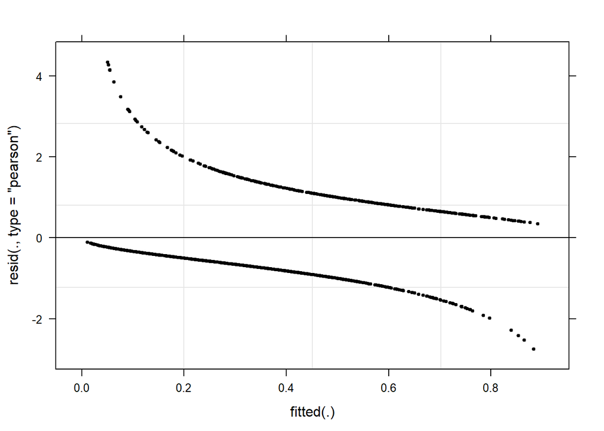

```r
par(mfrow = c(1, 4))   # display plots in 3 rows and 2 columns
plot(m6.glmer, col = "black", pch = 20); par(mfrow = c(1, 1))
```

The residuals are symetrical and do not exhibit a funnel shape which is good. We now plot Cook’s distance to check if we need to remove data points and include a data-driven cutoff threshold (which is likely too low).

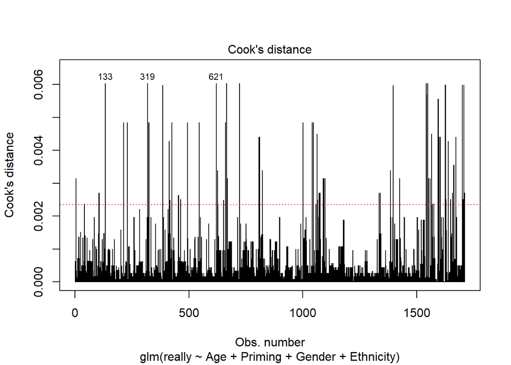

```r
# determine a cutoff for data points that have D-values higher than 4/(n-k-1)
cutoff <- 4/((nrow(reallywscnew)-length(coefficients(m6.glm)-2)))
# plot cook*s distance
plot(m6.glm, which=4, cook.levels = cutoff)
abline(h = cutoff, col = "red", lty = "dotted")
```

The Cook’s distance plot looks a lot better and the data points are distributed much more evenly.

We continue the diagnostics using the glm model and visualizing its residuals.

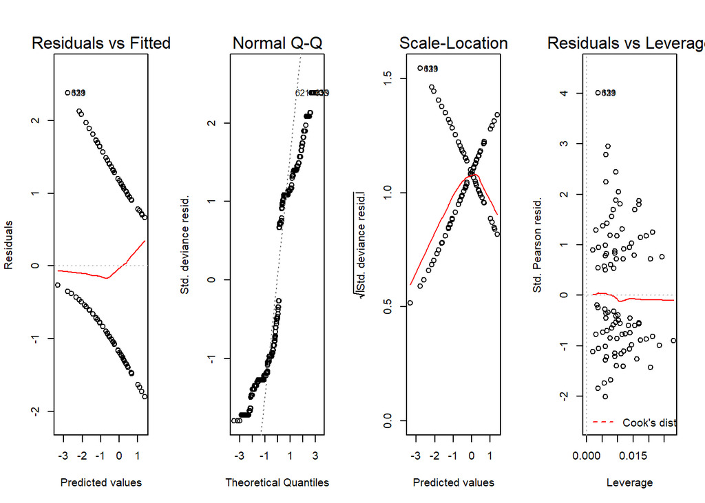

```r
# start plotting
par(mfrow = c(1, 4))
plot(m6.glm); par(mfrow = c(1, 4))
```

The diagnostics show that the data still do not fit the assumptions of the model really well but the situation has improved but we have to accept this as there is not much we can do. Also, the plot does not take the random effect structure into account which is like to have a really positive impact on the fit as the random intercepts by Adjective explained a significant and substantial amount of variance. We will now perform a power analysis to check if the sample size was sufficient to arrive at robust conclusions.

```r
# load package
library(simr)
# restructure data
preallywscnew <- reallywscnew %>%
  dplyr::select(Age, Priming, Gender, Ethnicity, Adjective, really) %>%
  dplyr::mutate(other = ifelse(really == "really", 0, 1)) %>%
  dplyr::mutate(really = ifelse(really == "really", 1, 0)) %>%
  dplyr::group_by(Age, Priming, Gender, Ethnicity, Adjective) %>%
  dplyr::summarise(really = sum(really), other = sum(other))
# redo model
gm1 <- glmer(cbind(really, other) ~ Age + Priming + Gender + Ethnicity + (1 | Adjective),
             data = preallywscnew, family = binomial,
             control = glmerControl(optimizer="bobyqa",
                                    optCtrl = list(maxIter = 100)))
# set seed for replicability
set.seed(2020011401)
# calculate power for Age
powerSim(gm1, fixed("Age", "lr"), nsim=100)
```

[output not shown]

```
## Power for predictor 'Age', (95% confidence interval):
##       100.0% (96.38, 100.0)
##
## Test: Likelihood ratio
##
## Based on 100 simulations, (100 warnings, 0 errors)
## alpha = 0.05, nrow = 1922
##
## Time elapsed: 0 h 3 m 28 s
##
## nb: result might be an observed power calculation
```

The power analysis confrims that the sample size is not only sufficient but even excessive and would have detected an effect the size of age in 100 percent of cases (lower ci 96.38, higher ci 100). The target is merely a standard of 80 percent in clinical trials!

```r
# set seed for replicability
set.seed(2019121202)
# calculate power for Priming
powerSim(gm1, fixed("Priming", "lr"), nsim=100)
```

[output not shown]

```
## Power for predictor 'Priming', (95% confidence interval):
##       100.0% (96.38, 100.0)
##
## Test: Likelihood ratio
##
## Based on 100 simulations, (100 warnings, 0 errors)
## alpha = 0.05, nrow = 1922
##
## Time elapsed: 0 h 4 m 33 s
##
## nb: result might be an observed power calculation
```

We will now check if the sample size is sufficient to detect a small effect (Cohen’s d 0.2) - the traditional scale is 0.2 for a small, 0.5 for medium sized, and 0.8 for a large or strong effect.

To test this, we check if the sample size of the model is sufficient to find a small effect. In order to check what a small effect is, we need to determine the odds ratios of the fixed effects and then convert them into Cohen’s d values for which we have associations between traditional denominations (small, medium, and large) and effect sife values. According to Chen, Cohen, and Chen (2010) odds ratios of 1.68, 3.47, and 6.71 are equivalent to Cohen’s d = 0.2 (small), 0.5 (medium), and 0.8 (large).

```r
estimatesfixedeffects <- fixef(gm1)
exp(estimatesfixedeffects)
```

```
##           (Intercept)              Age20-29              Age30-39
##             0.2161421             1.0982871             0.9226144
##              Age40-49                Age50+          PrimingPrime
##             0.3758159             0.1196758             2.5944468
##           GenderWoman EthnicityMAORI/PAKEHA        EthnicityOTHER
##             2.2121280             1.0746720             2.2431683
##       EthnicityPAKEHA
##             1.7539711
```

We will now change the size of the effect of Age20-29 to make it “small”, i.e. on the brink of being noise but being just strong enough to be considered small. In other words, we will set the effect so that its odds ratio is exactly 1.68.

```r
fixef(gm1)["Age20-29"] <- 0.519
estimatesfixedeffects <- fixef(gm1)
exp(estimatesfixedeffects)
```

```
##           (Intercept)              Age20-29              Age30-39
##             0.2161421             1.6803465             0.9226144
##              Age40-49                Age50+          PrimingPrime
##             0.3758159             0.1196758             2.5944468
##           GenderWoman EthnicityMAORI/PAKEHA        EthnicityOTHER
##             2.2121280             1.0746720             2.2431683
##       EthnicityPAKEHA
##             1.7539711
```

A small effect size would be equivalent to an estimate of 0.519.

We have now defined the effect size of Age20-29 to be the smallest meaningful effect. We can now test, if the model is powerful enough to detect this small effect with a likelihood high than 80 percent.

```r
# set seed for replicability
set.seed(2020011402)
fixef(gm1)["Age20-29"] <- 0.519
powerSim(gm1, fixed("Age20-29", "z"), nsim=100)
```

[output not shown]

```
## Power for predictor 'Age20-29', (95% confidence interval):
##       57.00% (46.71, 66.86)
##
## Test: z-test
##       Effect size for Age20-29 is 0.52
##
## Based on 100 simulations, (100 warnings, 0 errors)
## alpha = 0.05, nrow = 1922
##
## Time elapsed: 0 h 2 m 35 s
```

```r
fixef(gm1)["Age20-29"] <- 1.245
estimatesfixedeffects <- fixef(gm1)
exp(estimatesfixedeffects)
```

```
##           (Intercept)              Age20-29              Age30-39
##             0.2161421             3.4729348             0.9226144
##              Age40-49                Age50+          PrimingPrime
##             0.3758159             0.1196758             2.5944468
##           GenderWoman EthnicityMAORI/PAKEHA        EthnicityOTHER
##             2.2121280             1.0746720             2.2431683
##       EthnicityPAKEHA
##             1.7539711
```

A medium effect size size would be equivalent to an estimate of 1.245.

```r
# set seed for replicability
set.seed(2020011403)
fixef(gm1)["Age20-29"] <- 1.245
powerSim(gm1, fixed("Age20-29", "z"), nsim=100)
```

[output not shown]

```
## Power for predictor 'Age20-29', (95% confidence interval):
##       100.0% (96.38, 100.0)
##
## Test: z-test
##       Effect size for Age20-29 is 1.2
##
## Based on 100 simulations, (100 warnings, 0 errors)
## alpha = 0.05, nrow = 1922
##
## Time elapsed: 0 h 2 m 46 s
```

Our model would detect a medium effect in 100 percent of cases. We will now check the effect size at which our model would find an effect with 80 percent accuracy.

```r
# set seed for replicability
set.seed(2020011404)
fixef(gm1)["Age20-29"] <- 0.68 # 0.68 = 80%; 0.65 = 75%, 0.7 = 84%, 0.8 = 89%
powerSim(gm1, fixed("Age20-29", "z"), nsim=100)
```

[output not shown]

[output not shown]

```r
exp(fixef(gm1))
```

```
##           (Intercept)              Age20-29              Age30-39
##             0.2161421             1.9738777             0.9226144
##              Age40-49                Age50+          PrimingPrime
##             0.3758159             0.1196758             2.5944468
##           GenderWoman EthnicityMAORI/PAKEHA        EthnicityOTHER
##             2.2121280             1.0746720             2.2431683
##       EthnicityPAKEHA
##             1.7539711
```

After confirming that the samle size is sufficient for our analysis, we can summarize the results of the analysis.

```r
# load function for regression table summary
source("D:\\R/meblr.summary.R")
# set up summary table
meblrm_ampwsc <- meblrm.summary(m0.glm, m6.glm, m0.glmer, m6.glmer, reallywscnew$really)
# save results to disc
write.table(meblrm_ampwsc, "datatables/meblrm_ampwsc.txt", sep="\t")
# inspect result summary
meblrm_ampwsc
```

```
##                              Group(s) Variance Std. Dev.
## Random Effect(s)            Adjective     0.38      0.62
## Fixed Effect(s)              Estimate      VIF OddsRatio CI(2.5%) CI(97.5%)
## (Intercept)                     -1.53               0.22     0.13      0.37
## Age20-29                         0.09     1.77       1.1     0.82      1.47
## Age30-39                        -0.08     1.51      0.92     0.62      1.38
## Age40-49                        -0.98     1.33      0.38     0.23       0.6
## Age50+                          -2.12     1.22      0.12     0.07      0.21
## PrimingPrime                     0.95     1.01      2.59     1.93      3.49
## GenderWoman                      0.79     1.01      2.21     1.74      2.81
## EthnicityMAORI/PAKEHA            0.07     1.44      1.07     0.54      2.13
## EthnicityOTHER                   0.81      2.2      2.24     1.34      3.76
## EthnicityPAKEHA                  0.56     2.48      1.75     1.16      2.64
## Model statistics
## Number of Groups
## Number of cases in model
## Observed misses
## Observed successes
## Residual deviance
## R2 (Nagelkerke)
## R2 (Hosmer & Lemeshow)
## R2 (Cox & Snell)
## C
## Somers' Dxy
## AIC
## BIC
## Prediction accuracy
## Model Likelihood Ratio Test
##                                     L.R. X2      DF         Pr     Significance
## Random Effect(s)                     100.53       1          0      p < .001***
## Fixed Effect(s)                  Std. Error z value   Pr(>|z|)     Significance
## (Intercept)                            0.27   -5.65          0      p < .001***
## Age20-29                               0.15    0.62     0.5325             n.s.
## Age30-39                               0.21   -0.39      0.696             n.s.
## Age40-49                               0.24   -4.06          0      p < .001***
## Age50+                                 0.28   -7.46          0      p < .001***
## PrimingPrime                           0.15    6.28          0      p < .001***
## GenderWoman                            0.12    6.46          0      p < .001***
## EthnicityMAORI/PAKEHA                  0.35    0.21     0.8371             n.s.
## EthnicityOTHER                         0.26    3.07     0.0022      p <  .01 **
## EthnicityPAKEHA                        0.21    2.69     0.0073      p <  .01 **
## Model statistics                                                          Value
## Number of Groups                                                            261
## Number of cases in model                                                   1711
## Observed misses                                                               0
## Observed successes                                                            0
## Residual deviance                                                       2020.64
## R2 (Nagelkerke)                                                           0.319
## R2 (Hosmer & Lemeshow)                                                    0.198
## R2 (Cox & Snell)                                                          0.238
## C                                                                         0.794
## Somers' Dxy                                                               0.588
## AIC                                                                     2042.64
## BIC                                                                     2102.53
## Prediction accuracy                                                         NA%
## Model Likelihood Ratio Test L.R. X2: 334.19  DF: 10 p-value: 0 sig: p < .001***
```

We also check the Anova summary to see if predictors, rather than individual predictor levels, are significant and to what extent.

```r
# load function
library(car)
meblrm_ampwsc_Anova <- Anova(m6.glmer, type = "III", test = "Chi")
# save results to disc
write.table(meblrm_ampwsc_Anova, "datatables/meblrm_ampwsc_Anova.txt", sep="\t")
# inspect results in Anova style
meblrm_ampwsc_Anova
```

```
## Analysis of Deviance Table (Type III Wald chisquare tests)
##
## Response: really
##              Chisq Df            Pr(>Chisq)
## (Intercept) 31.928  1       0.0000000160000 ***
## Age         86.500  4 < 0.00000000000000022 ***
## Priming     39.423  1       0.0000000003412 ***
## Gender      41.729  1       0.0000000001048 ***
## Ethnicity   12.523  3               0.00579 **
## ---
## Signif. codes:  0 '***' 0.001 '**' 0.01 '*' 0.05 '.' 0.1 ' ' 1
```

We will also inspect the effects of the individual predcitors. We begin with Age.

```r
effectage <- anova(m1.glmer, m0.glmer, test = "Chi")
effectage
```

```
## Data: reallywscnew
## Models:
## m0.glmer: really ~ (1 | Adjective)
## m1.glmer: really ~ (1 | Adjective) + Age
##          Df    AIC    BIC  logLik deviance  Chisq Chi Df            Pr(>Chisq)
## m0.glmer  2 2258.3 2269.2 -1127.2   2254.3
## m1.glmer  6 2135.7 2168.3 -1061.8   2123.7 130.62      4 < 0.00000000000000022
##
## m0.glmer
## m1.glmer ***
## ---
## Signif. codes:  0 '***' 0.001 '**' 0.01 '*' 0.05 '.' 0.1 ' ' 1
```

Now, we inspect the effect of Priming.

```r
effectpriming <- anova(m2.glmer, m1.glmer, test = "Chi")
effectpriming
```

```
## Data: reallywscnew
## Models:
## m1.glmer: really ~ (1 | Adjective) + Age
## m2.glmer: really ~ (1 | Adjective) + Age + Priming
##          Df    AIC    BIC  logLik deviance  Chisq Chi Df       Pr(>Chisq)
## m1.glmer  6 2135.7 2168.3 -1061.8   2123.7
## m2.glmer  7 2091.8 2129.9 -1038.9   2077.8 45.906      1 0.00000000001241 ***
## ---
## Signif. codes:  0 '***' 0.001 '**' 0.01 '*' 0.05 '.' 0.1 ' ' 1
```

Now, we inspect the effect of Gender.

```r
effectgender <- anova(m4.glmer, m2.glmer, test = "Chi")
effectgender
```

```
## Data: reallywscnew
## Models:
## m2.glmer: really ~ (1 | Adjective) + Age + Priming
## m4.glmer: really ~ (1 | Adjective) + Age + Priming + Gender
##          Df    AIC    BIC  logLik deviance  Chisq Chi Df       Pr(>Chisq)
## m2.glmer  7 2091.8 2129.9 -1038.9   2077.8
## m4.glmer  8 2049.4 2093.0 -1016.7   2033.4 44.344      1 0.00000000002755 ***
## ---
## Signif. codes:  0 '***' 0.001 '**' 0.01 '*' 0.05 '.' 0.1 ' ' 1
```

Now, we inspect the effect of Ethnicity.

```r
effectethnicity <- anova(m6.glmer, m4.glmer, test = "Chi")
effectethnicity
```

```
## Data: reallywscnew
## Models:
## m4.glmer: really ~ (1 | Adjective) + Age + Priming + Gender
## m6.glmer: really ~ (1 | Adjective) + Age + Priming + Gender + Ethnicity
##          Df    AIC    BIC  logLik deviance  Chisq Chi Df Pr(>Chisq)
## m4.glmer  8 2049.4 2093.0 -1016.7   2033.4
## m6.glmer 11 2042.6 2102.5 -1010.3   2020.6 12.795      3   0.005102 **
## ---
## Signif. codes:  0 '***' 0.001 '**' 0.01 '*' 0.05 '.' 0.1 ' ' 1
```

In a next step, we create a summary of the model fitting process.

```r
# use customized model comparison function
# create comparireallyns
m1m0 <- anova(m0.glmer, m1.glmer, test = "Chi")
m2m1 <- anova(m2.glmer, m1.glmer, test = "Chi")
m3m2 <- anova(m3.glmer, m2.glmer, test = "Chi")
m4m2 <- anova(m4.glmer, m2.glmer, test = "Chi")
m5m4 <- anova(m5.glmer, m4.glmer, test = "Chi")
m6m4 <- anova(m6.glmer, m4.glmer, test = "Chi")
m7m6 <- anova(m7.glmer, m6.glmer, test = "Chi")
m8m6 <- anova(m8.glmer, m6.glmer, test = "Chi")
m9m6 <- anova(m9.glmer, m6.glmer, test = "Chi")
m12m6 <- anova(m12.glmer, m6.glmer, test = "Chi")
m13m6 <- anova(m13.glmer, m6.glmer, test = "Chi")
m14m6 <- anova(m14.glmer, m6.glmer, test = "Chi")
m15m6 <- anova(m15.glmer, m6.glmer, test = "Chi")
m16m6 <- anova(m16.glmer, m6.glmer, test = "Chi")
m18m6 <- anova(m18.glmer, m6.glmer, test = "Chi")
m22m6 <- anova(m22.glmer, m6.glmer, test = "Chi")
# create a list of the model comparireallyns
mdlcmp <- list(m1m0, m2m1, m3m2, m4m2, m5m4, m6m4, m7m6, m8m6, m9m6, m12m6,
               m13m6, m14m6, m15m6, m16m6, m18m6, m22m6)
# load function
source("D:\\R/ModelFittingSummarySWSU.R") # for Mixed Effects Model fitting (step-wise step-up): Binary Logistic Mixed Effects Models
# apply function
mdl.cmp.glmersc.swsu.dm <- mdl.fttng.swsu(mdlcmp)
# save comparisons to disc
write.table(mdl.cmp.glmersc.swsu.dm, "datatables/mdl_cmp_glmersc_swsu_reallywscnew.txt", sep="\t")
# inspect output
mdl.cmp.glmersc.swsu.dm
```

```
##        Model
## 1   m1.glmer
## 2   m2.glmer
## 3   m3.glmer
## 4   m4.glmer
## 5   m5.glmer
## 6   m6.glmer
## 7   m7.glmer
## 8   m8.glmer
## 9   m9.glmer
## 10 m12.glmer
## 11 m13.glmer
## 12 m14.glmer
## 13 m15.glmer
## 14 m16.glmer
```

[output cut: 53 more lines]

In a next step, we perform Post-hoc analysis by using post-hoc Turkey tests to check which vpredictor levels are significant compared to each other. We begin with individual age levels.

```r
library (multcomp)
summary(glht(m6.glmer, mcp(Age="Tukey")))
```

```
##
##   Simultaneous Tests for General Linear Hypotheses
##
## Multiple Comparisons of Means: Tukey Contrasts
##
##
## Fit: glmer(formula = really ~ (1 | Adjective) + Age + Priming + Gender +
##     Ethnicity, data = reallywscnew, family = binomial, control = glmerControl(optimizer = "bobyqa"))
##
## Linear Hypotheses:
##                    Estimate Std. Error z value Pr(>|z|)
## 20-29 - 16-19 == 0  0.09375    0.15021   0.624  0.96892
## 30-39 - 16-19 == 0 -0.08054    0.20612  -0.391  0.99464
## 40-49 - 16-19 == 0 -0.97865    0.24089  -4.063  < 0.001 ***
## 50+ - 16-19 == 0   -2.12297    0.28452  -7.462  < 0.001 ***
## 30-39 - 20-29 == 0 -0.17430    0.17662  -0.987  0.85218
## 40-49 - 20-29 == 0 -1.07241    0.21778  -4.924  < 0.001 ***
## 50+ - 20-29 == 0   -2.21672    0.26562  -8.346  < 0.001 ***
## 40-49 - 30-39 == 0 -0.89811    0.25410  -3.534  0.00344 **
## 50+ - 30-39 == 0   -2.04243    0.29850  -6.842  < 0.001 ***
## 50+ - 40-49 == 0   -1.14431    0.32025  -3.573  0.00299 **
## ---
## Signif. codes:  0 '***' 0.001 '**' 0.01 '*' 0.05 '.' 0.1 ' ' 1
## (Adjusted p values reported -- single-step method)
```

```r
summary(glht(m6.glmer, mcp(Ethnicity="Tukey")))
```

```
##
##   Simultaneous Tests for General Linear Hypotheses
##
## Multiple Comparisons of Means: Tukey Contrasts
##
##
## Fit: glmer(formula = really ~ (1 | Adjective) + Age + Priming + Gender +
##     Ethnicity, data = reallywscnew, family = binomial, control = glmerControl(optimizer = "bobyqa"))
##
## Linear Hypotheses:
##                            Estimate Std. Error z value Pr(>|z|)
## MAORI/PAKEHA - MAORI == 0   0.07201    0.35023   0.206   0.9967
## OTHER - MAORI == 0          0.80789    0.26352   3.066   0.0106 *
## PAKEHA - MAORI == 0         0.56188    0.20926   2.685   0.0334 *
## OTHER - MAORI/PAKEHA == 0   0.73587    0.33203   2.216   0.1097
## PAKEHA - MAORI/PAKEHA == 0  0.48987    0.29463   1.663   0.3252
## PAKEHA - OTHER == 0        -0.24601    0.18210  -1.351   0.5105
## ---
## Signif. codes:  0 '***' 0.001 '**' 0.01 '*' 0.05 '.' 0.1 ' ' 1
## (Adjusted p values reported -- single-step method)
```

Now, we inspect the amount of variance that the final minimal model explains.

```r
# inspect results of minimal adequate model
#summary(m6.glmer)
# inspect results of baseline model
#summary(m0.glmer)
# explained variance ((null-deviance-residual deviance)/null-deviance)*100
((2254.3-2020.6)/2254.3)*100
```

```
## [1] 10.36685
```

The model explains 10.36685 percent of the variance.

We now check the prediction accuracy of the final minimal model.

```r
# predict probs of nativelike for effects
reallywscnew$PredictedFrequency <- predict(m6.glmer, reallywscnew, type="response")
#summary(reallywscnew$PredictedFrequency)
# create response variable
reallywscnew$PredictedResponse <- ifelse(reallywscnew$PredictedFrequency > .5, "really", "other")
#summary(reallywscnew$PredictedResponse)
# load library
library(caret)
# create confusion matrix
confusionMatrix(as.factor(reallywscnew$PredictedResponse), as.factor(reallywscnew$really))
```

```
## Confusion Matrix and Statistics
##
##           Reference
## Prediction other really
##     other    719    247
##     really   222    523
##
##                Accuracy : 0.7259
##                  95% CI : (0.7041, 0.7469)
##     No Information Rate : 0.55
##     P-Value [Acc > NIR] : <0.0000000000000002
##
##                   Kappa : 0.4446
##
##  Mcnemar's Test P-Value : 0.2678
##
##             Sensitivity : 0.7641
##             Specificity : 0.6792
##          Pos Pred Value : 0.7443
##          Neg Pred Value : 0.7020
##              Prevalence : 0.5500
##          Detection Rate : 0.4202
##    Detection Prevalence : 0.5646
##       Balanced Accuracy : 0.7217
##
##        'Positive' Class : other
##
```

We now turn to the visualization of the effecst of the final minimal model. We will vizualize the effects by plotting the predictions fro the different predictor levels. We begin with visualizing the effect of Priming.

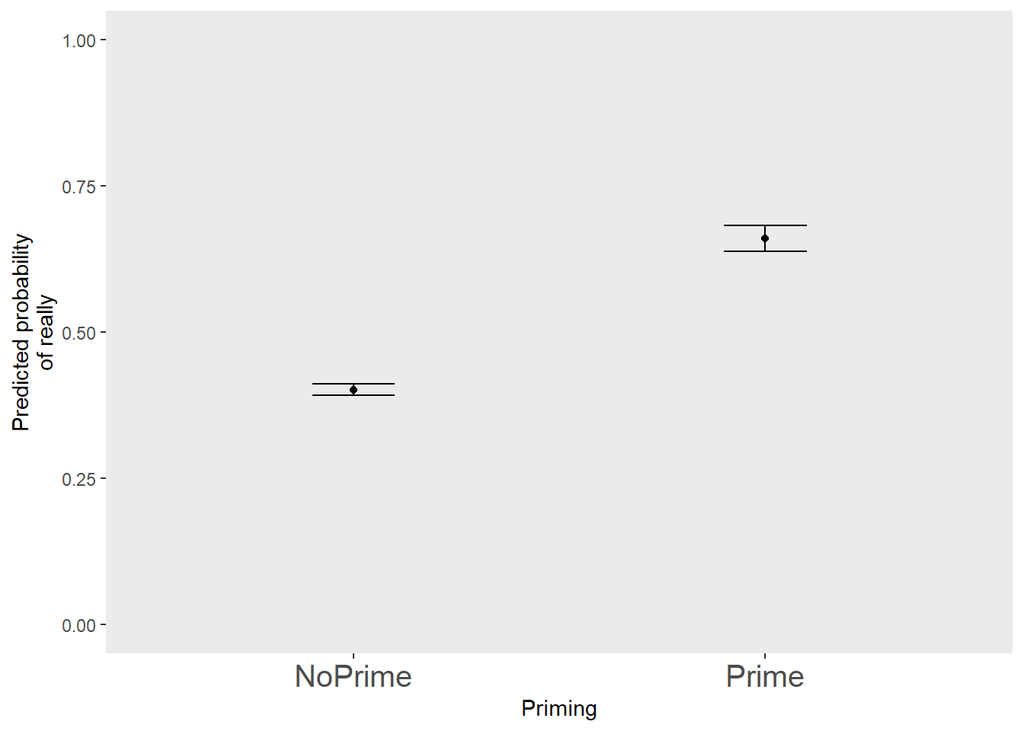

```r
# prepare plot data (pd)
pd <- reallywscnew

# effect Priming
p5 <- ggplot(pd, aes(x = Priming, y = PredictedFrequency)) +
  stat_summary(fun.y = mean, geom = "point") +
  stat_summary(fun.data = mean_cl_boot, geom = "errorbar", width = 0.2) +
  coord_cartesian(ylim = c(0, 1)) +
  theme_set(theme_bw(base_size = 20)) +
    theme(legend.position="none",
        axis.text.x = element_text(size=15),
        panel.grid.major = element_blank(),
        panel.grid.minor = element_blank()) +
  labs(x = "Priming", y = "Predicted probability\nof really") +
  ggsave(file = paste(imageDirectory,"PredictedPriming.png",sep="/"),
       height = 5,  width = 7,  dpi = 320)
p5
```

We now turn to the visualization of the Gender effect.

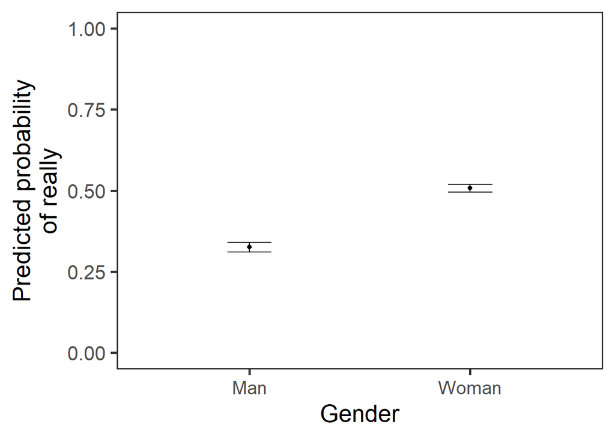

```r
# effect Gender
p6 <- ggplot(pd, aes(x = Gender, y = PredictedFrequency)) +
  stat_summary(fun.y = mean, geom = "point") +
  stat_summary(fun.data = mean_cl_boot, geom = "errorbar", width = 0.2) +
  coord_cartesian(ylim = c(0, 1)) +
  theme_set(theme_bw(base_size = 20)) +
    theme(legend.position="none",
        axis.text.x = element_text(size=15),
        panel.grid.major = element_blank(),
        panel.grid.minor = element_blank()) +
  labs(x = "Gender", y = "Predicted probability\nof really") +
  ggsave(file = paste(imageDirectory,"PredictedGender.png",sep="/"),
       height = 5,  width = 7,  dpi = 320)
p6
```

We now turn to the visualization of the Etnicity effect.

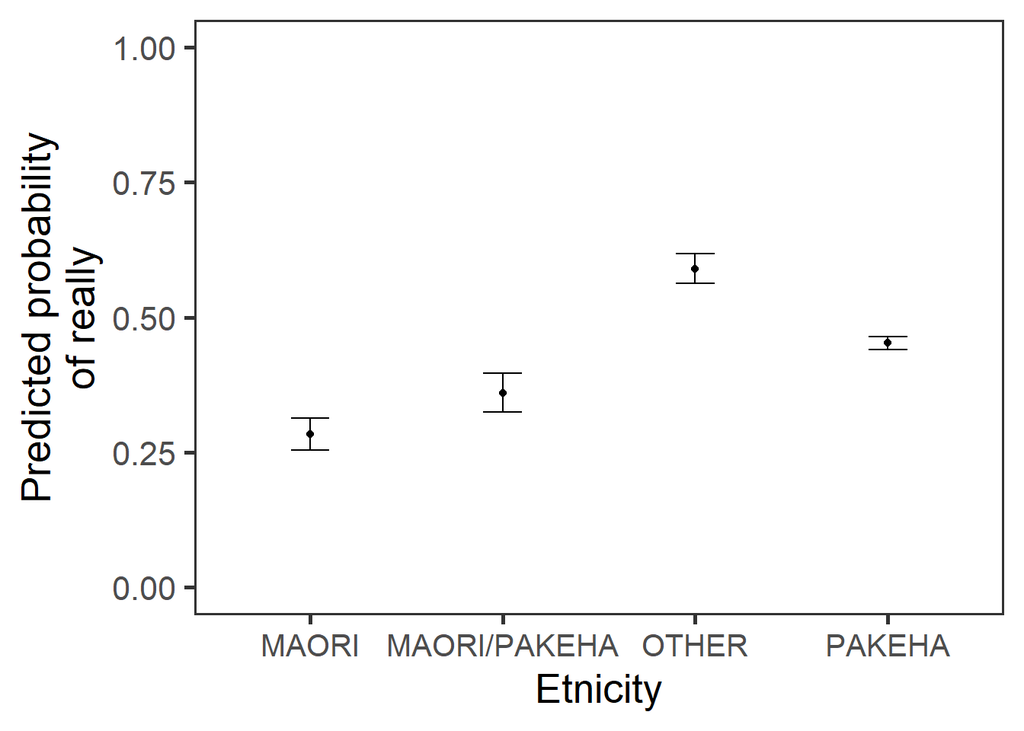

```r
# effect Etnicity
p7 <- ggplot(pd, aes(x = Ethnicity, y = PredictedFrequency)) +
  stat_summary(fun.y = mean, geom = "point") +
  stat_summary(fun.data = mean_cl_boot, geom = "errorbar", width = 0.2) +
  coord_cartesian(ylim = c(0, 1)) +
  theme_set(theme_bw(base_size = 20)) +
    theme(legend.position="none",
        axis.text.x = element_text(size=15),
        panel.grid.major = element_blank(),
        panel.grid.minor = element_blank()) +
  labs(x = "Etnicity", y = "Predicted probability\nof really") +
  ggsave(file = paste(imageDirectory,"PredictedEthnicity.png",sep="/"),
       height = 5,  width = 7,  dpi = 320)
p7
```

We now turn to the visualization of the age effect.

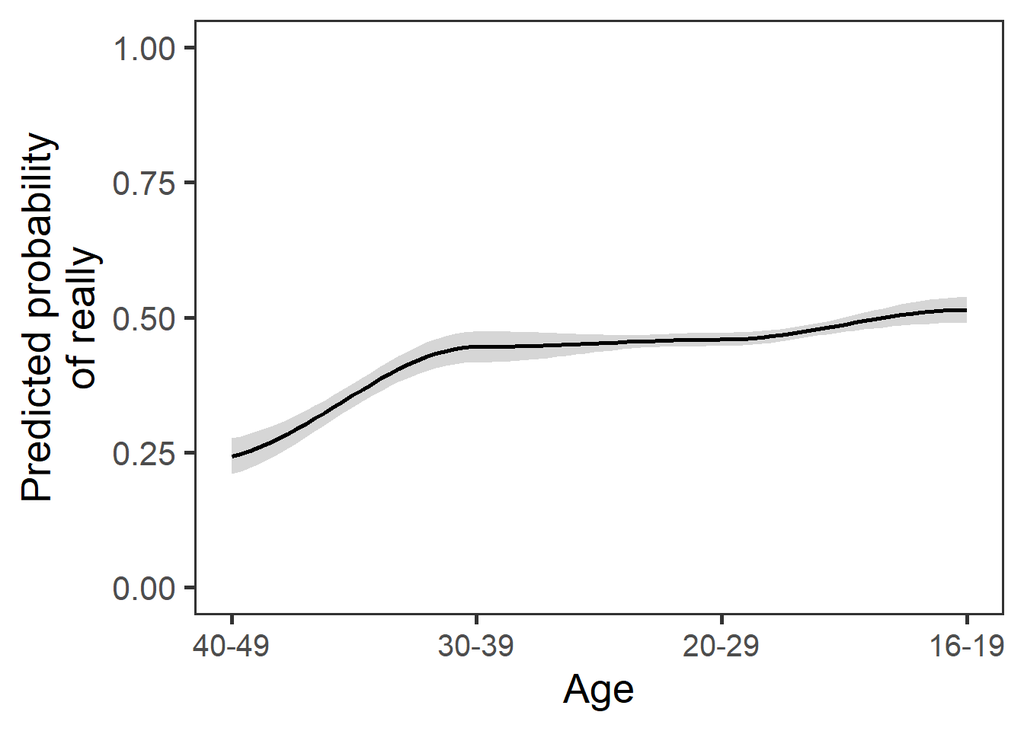

```r
# convert Age column
Agelbs <- c("16-19", "20-29", "30-39", "40-49", "50-59", "60+")
pd$Age <- ifelse(pd$Age == "16-19", 6,
                 ifelse(pd$Age == "20-29", 5,
                        ifelse(pd$Age == "30-39", 4,
                               ifelse(pd$Age == "40-49", 3,
                                      ifelse(pd$Age == "50-59", 2,
                                             ifelse(pd$Age == "60+", 1, pd$Age))))))
pd$Age<- as.numeric(pd$Age)
# effect age
p8 <- ggplot(pd, aes(x = Age, y = PredictedFrequency)) +
  geom_smooth(aes(y = PredictedFrequency, x = Age),
              colour="black", size=1, se = T, method = "loess") +
  coord_cartesian(ylim = c(0, 1)) +
  theme_set(theme_light(base_size = 15)) +
  theme(legend.position="none",
        axis.text.x = element_text(size=15),
        panel.grid.major = element_blank(),
        panel.grid.minor = element_blank()) +
  labs(x = "Frequency of adj. type", y = "Predicted probability\nof really") +
  scale_x_continuous(name = "Age",
                     breaks = c(1, 2, 3, 4, 5, 6),
                     labels=rev(Agelbs))
ggsave(file = paste(imageDirectory,"PredictedAge.png",sep="/"),
       height = 5,  width = 7,  dpi = 320)
p8
```

In addition to plotting the predicted values of the predictor levels, we also plot the effects directly using the effects package.

```r
library(effects)
png("images/effectsfinalmodel.png",  width = 960, height = 480)
plot(allEffects(m6.glmer), type="response", ylim=c(0,1), grid=TRUE,
     lines = list(col="black",
                  lty = 1,
                  confint=list(style="bars",
                               col = "grey80")),
     ylab = "Prob (really)")
dev.off()
```

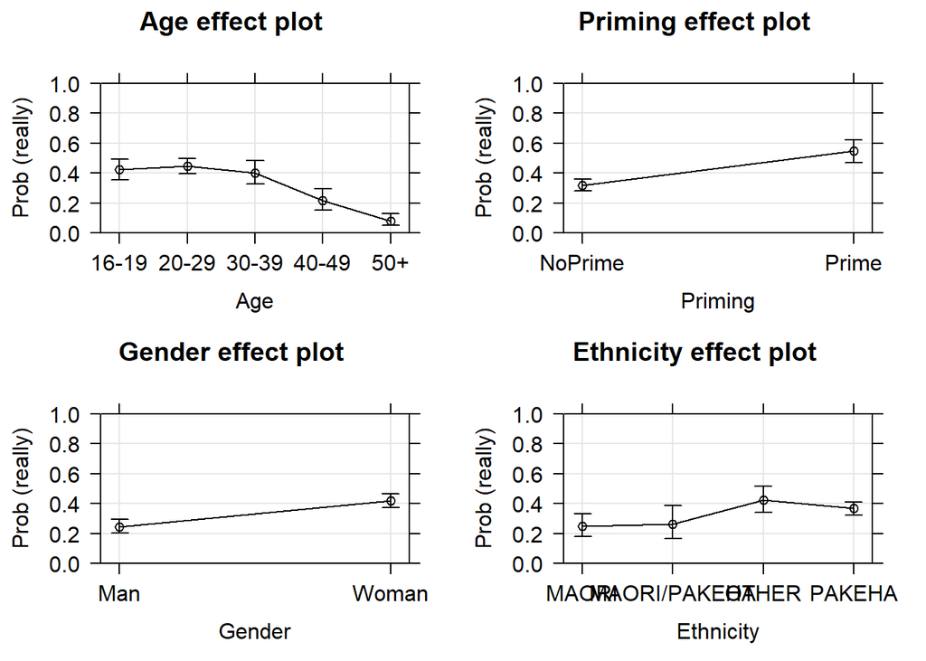

```r
plot(allEffects(m6.glmer), type="response", ylim=c(0,1), grid=TRUE,
     lines = list(col="black",
                  lty = 1,
                  confint=list(style="bars",
                               col = "grey80")),
     ylab = "Prob (really)")
```

```r
randomtb <- ranef(m6.glmer)
rndmadj <- as.vector(unlist(randomtb$`Adjective`))
adj <- as.vector(unlist(rownames(randomtb$`Adjective`)))
rndmadjtb <- data.frame(adj, rndmadj)
colnames(rndmadjtb) <- c("Adjective", "Intercept")
rndmadjtb <- rndmadjtb[order(rndmadjtb$Intercept, decreasing = T),]
rndmadjtb
```

```
##         Adjective     Intercept
## 91           good  0.9846242857
## 41           cool  0.9070569957
## 248         weird  0.8354576092
## 94          great  0.8339227529
## 149          nice  0.7787132603
## 85    frustrating  0.6641381269
## 64          early  0.6600125283
## 261         yummy  0.6317815727
## 122   interesting  0.5749607161
## 153           odd  0.5731088553
## 192         short  0.5385219518
## 37    comfortable  0.5125440389
## 236         upset  0.4997367299
## 14            bad  0.4936330401
```

[output cut: 247 more lines]

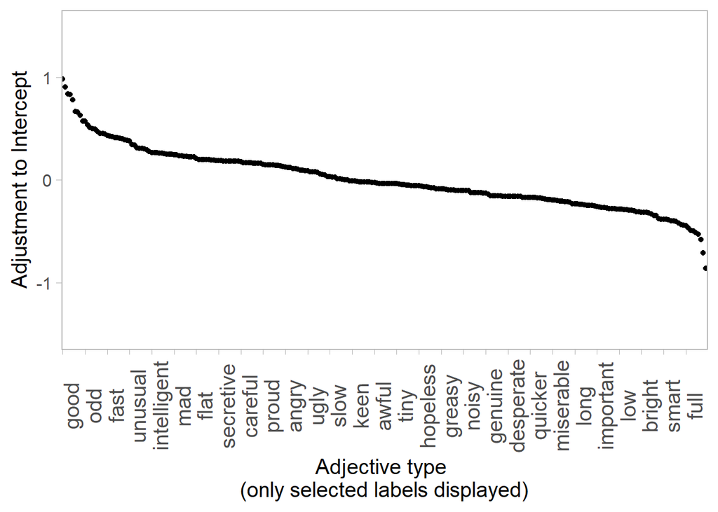

```r
p9 <- ggplot(rndmadjtb, aes(Adjective, Intercept)) +
  geom_point(aes(reorder(Adjective, -Intercept, fun = Intercept), y=Intercept)) +
  coord_cartesian(ylim = c(-1.5, 1.5)) +
  theme_set(theme_bw(base_size = 15)) +
  theme(legend.position="none",
        axis.text.x = element_text(size=15, angle=90),
        panel.grid.major = element_blank(),
        panel.grid.minor = element_blank()) +
  scale_x_discrete(breaks = rndmadjtb$Adjective[seq(1,length(rndmadjtb$Adjective),9)]) +
  labs(x = "Adjective type \n(only selected labels displayed)", y = "Adjustment to Intercept")
ggsave(file = paste(imageDirectory,"RanAdjective.png",sep="/"),
       height = 5,  width = 7.5,  dpi = 320)
# activate (remove #) to show
p9
```

In a final step, we create a table which shows the sample size at different stages of the analysis. In a first step, we extract the number of adjectives.

```r
# load data sets
raw <- read.delim("datatables/wscadjdf.txt", sep = "\t", header = T, quote = "\"", skipNul = T)
processed <- read.delim("datatables/ampwsc.txt", sep = "\t", header = T, quote = "\"", skipNul = T)
processed <- processed %>%
  dplyr::select(-AgeNumeric) %>%
  dplyr::mutate(FileSpeaker = paste(File, Speaker, sep = ""))  %>%
  dplyr::mutate(really = ifelse(Variant == "really", "really", "other")) %>%
  na.omit()
statz1 <- read.delim("datatables/ampwsc.txt", sep = "\t", header = T, quote = "\"", skipNul = T)
statz1 <- statz1 %>%
  dplyr::filter(Variant != "0") %>%
  dplyr::select(-AgeNumeric) %>%
  dplyr::mutate(FileSpeaker = paste(File, Speaker, sep = ""))  %>%
  dplyr::mutate(really = ifelse(Variant == "really", "really", "other")) %>%
  na.omit()
cutoff <- 0.007
statz2 <- statz1[-(which(reallywsc$cooksdistance > cutoff)),]
# extract number of adjectives
token_raw <- nrow(raw)
token_processed <- nrow(processed)
token_statz1 <- nrow(statz1)
token_statz2 <- nrow(statz2)
# create vector
adjsN <- c(token_raw, token_processed, token_statz1, token_statz2)
# inspect vector
adjsN
```

```
## [1] 57132 11285  1715  1713
```

Now, we extract the number of speakers.

```r
# extract number of speakers
speaker_raw <- length(table(paste(raw$File, raw$Speaker, sep = "")))
speaker_processed <- length(table(processed$FileSpeaker))
speaker_statz1 <- length(table(statz1$FileSpeaker))
speaker_stat2 <- length(table(statz2$FileSpeaker))
# create vector
spkrsN <- c(speaker_raw, speaker_processed, speaker_statz1, speaker_stat2)
# inspect vector
spkrsN
```

```
## [1] 1434  531  441  441
```

Now, we extract the number of amplified slots.

```r
# extract number of amplified slots
# we first need to determine the number of amplifier slots for the raw data
# vecttor of amplifiers
# define amplifiers
amplifiers <- c("absolutely", "actually", "aggressively",
                "amazingly", "appallingly", "awful", "awfully",
                "badly", "bloody", "certainly", "clearly",
                "complete", "dead", "completely", "considerably",
                "crazy", "decidedly", "definitely",  "distinctly",
                "dreadfully", "enormously", "entirely", "especially",
                "exactly", "exceedingly", "exceptionally",
                "excruciatingly", "extraordinarily", "extremely",
                "fiercely", "firmly", "frightfully", "fucking",
                "fully", "genuinely", "greatly",
                "grossly", "heavily", "highly", "hopelessly",
                "horrendously", "hugely",
                "immediately", "immensely", "incredibly",
                "infinitely", "intensely", "irrevocably",
                "mad", "mega", "mighty", "most", "much",
                "obviously", "openly", "overwhelmingly", "particularly",
                "perfectly", "plenty", "positively", "precisely",
                "pretty", "profoundly", "purely",
                #"quite",
                "real", "really", "remarkably", "seriously",
                "shocking",   "significant", "significantly", "so",
                "specially", "specifically", "strikingly",
                "strongly", "substantially", "super", "surely",
                "terribly", "terrifically",
                #"too",
                "total", "totally", "traditionally", "true",
                "truly", "ultra", "utterly", "really",
                "viciously",
                #"well",
                "wholly", "wicked", "wildly")
raw <- raw %>%
  dplyr::mutate(Variant = str_replace_all(tolower(Variant), "/.*", "")) %>%
  dplyr::mutate(Amplified = ifelse(Variant %in% amplifiers, 1, 0))
# extract number of amplified slots
amp_raw <- sum(raw$Amplified)
amp_processed <- sum(processed$Amplified)
amp_statz1 <- sum(statz1$Amplified)
amp_stat2 <- sum(statz2$Amplified)
# create vector
ampN <- c(amp_raw, amp_processed, token_statz1, token_statz2)
# inspect vector
ampN
```

```
## [1] 3285 1715 1715 1713
```

Now, we extract the number of amplified slots.

```r
# create table from results
Table0 <- data.frame(spkrsN, adjsN, ampN)
Table0 <- Table0 %>%
  dplyr::rename(Speakers = spkrsN, AdjectiveToken = adjsN,
                AmplifiedAdjectives = ampN) %>%
  dplyr::mutate(Percent = round(AmplifiedAdjectives/AdjectiveToken*100, 1))
rownames(Table0) <- c("raw data",  "processed data", "variable context data",
                      "variable context data without outliers")
# save table to disc
write.table(Table0, "datatables/Table0.txt", sep = "\t", row.names = T, col.names = T, quote = F)
# inspect vector
Table0
```

```
##                                        Speakers AdjectiveToken
## raw data                                   1434          57132
## processed data                              531          11285
## variable context data                       441           1715
## variable context data without outliers      441           1713
##                                        AmplifiedAdjectives Percent
## raw data                                              3285     5.7
## processed data                                        1715    15.2
## variable context data                                 1715   100.0
## variable context data without outliers                1713   100.0
```

We now have to recreate Table 2 bacuse we had to remove outliers during the model fitting.

```r
# create table
Table2 <- statz2 %>%
  dplyr::select(Age, Gender, FileSpeaker, really)  %>%
  dplyr::group_by(Age, Gender) %>%
  dplyr::summarize(Speakers = length(names(table(FileSpeaker))),
                   AdjectiveSlots = n(),
                   really = table(really)[2]) %>%
  dplyr::mutate(Percent = round(really/AdjectiveSlots*100, 2))
Table2 <- rbind(as.data.frame(Table2), c("", "", sum(Table2$Speakers),
                  sum(Table2$AdjectiveSlots),
                  sum(Table2$really), round(mean(Table2$Percent), 2)))
# save data to disc
write.table(Table2, "datatables/Table2.txt", sep = "\t", row.names = F)
# inspect Table2
Table2
```

```
##      Age Gender Speakers AdjectiveSlots really Percent
## 1  16-19    Man       26             77     30   38.96
## 2  16-19  Woman       47            224    125    55.8
## 3  20-29    Man       74            295    115   38.98
## 4  20-29  Woman      124            573    351   61.26
## 5  30-39    Man       26             67     21   31.34
## 6  30-39  Woman       35            136     70   51.47
## 7  40-49    Man       19             52     11   21.15
## 8  40-49  Woman       34            100     27      27
## 9    50+    Man       22             71      9   12.68
## 10   50+  Woman       34            118     13   11.02
## 11                   441           1713    772   34.97
```

```r
Varianttbwsc <- table(processed$Variant)
Varianttbwsc <- Varianttbwsc[order(table(processed$Variant), decreasing = T)]
Variantnames <- as.vector(names(Varianttbwsc))
Variantn <- as.vector(Varianttbwsc)
Variantprcnt <- round(Variantn/sum(Variantn)*100, 2)
Variantprcnt2 <-  c(0, round(Variantn[2:length(Variantn)]/sum(Variantn[2:length(Variantn)])*100, 2))
Table3 <- data.frame(Variantnames, Variantn, Variantprcnt, Variantprcnt2)
colnames(Table3) <- c("Variant", "TokenFrequency", "PercentageSlots", "PercentAgeAmplifiedensifiers")
Table3 <- rbind(Table3, c("Total", sum(as.vector(Table3$TokenFrequency)),
                          "", ""))
rownames(Table3) <- NULL
# save data to disc
write.table(Table3, "datatables/Table3.txt", sep = "\t", row.names = F)
# inspect data
Table3
```

```
##           Variant TokenFrequency PercentageSlots PercentAgeAmplifiedensifiers
## 1               0           9570            84.8                            0
## 2          really            774            6.86                        45.13
## 3            very            319            2.83                         18.6
## 4              so            250            2.22                        14.58
## 5          pretty            161            1.43                         9.39
## 6            real             50            0.44                         2.92
## 7      absolutely             19            0.17                         1.11
## 8          bloody             19            0.17                         1.11
## 9         totally             15            0.13                         0.87
## 10        fucking             13            0.12                         0.76
## 11     completely             11             0.1                         0.64
## 12     incredibly              7            0.06                         0.41
## 13   particularly              6            0.05                         0.35
## 14       actually              5            0.04                         0.29
```

[output cut: 37 more lines]

We have reached the end of the analysis of adjective amplifiers in New Zealand English.

# References

Chen, Henian, Patricia Cohen, and Sophie Chen. 2010. “How Big Is a Big Odds Ratio? Interpreting the Magnitudes of Odds Ratios in Epidemiological Studies.” *Communications in Statistics—Simulation and Computation* 39 (4): 860–64.